# Lyme Disease Differential Gene Expression Re-Analysis

Re-analysis of Bouquet et al. 2016 (GSE63085) using DESeq2 & clusterProfiler

Midani

2026-05-18

# Introduction

In this notebook, we re-analyse the publicly available RNA-seq dataset GSE63085 from Bouquet et al. 2016, which profiled peripheral blood gene expression in Lyme disease patients at multiple time points (acute infection, post-treatment, and 6-month follow-up) compared to healthy controls. The original study used:

- outdated hg19 reference genome,
- TopHat2/Cufflinks2 for alignment and quantification, and
- Limma/Voom for differential expression analysis, with pathway enrichment via the proprietary IPA tool.

Lyme disease is a tick-borne infection caused by *Borrelia burgdorferi*. It can lead to a range of symptoms, from acute flu-like illness to chronic fatigue and joint pain. Understanding the host immune response at the transcriptomic level can provide insights into disease mechanisms and potential therapeutic targets.

# Summary of the re-analysis Implementation

## How Our Re-Analysis Compares to the Original Study

| Aspect | Bouquet et al. 2016 | Our Re-Analysis |
| --- | --- | --- |
| Genome | hg19 (2009) | GRCh38.p13 (current) |
| Aligner | TopHat2/Cufflinks2 (deprecated) | Kallisto (modern) |
| Input data | FPKM (normalised) | Raw integer counts |
| DE method | Limma/Voom | DESeq2 (negative binomial) |
| Fold-change | Raw FC > 1.5 | Shrunken LFC (ashr) |
| Pathway tool | IPA (proprietary, 3$) | clusterProfiler + MSigDB (open-source, free) |
| Pathway methods | ORA only (1st gen) | ORA + GSEA + GSVA + SPIA (1st–3rd gen) |
| Per-sample resolution | No (bulk group comparison) | Yes (GSVA scores per patient) |

### What we confirmed

- A strong immune/inflammatory signature at V1 (acute Lyme)
- The signature persists beyond antibiotic treatment (V2)
- Partial recovery by 6 months (V5) but not to baseline
- TNF-alpha, interferons, complement, and IL-6 signaling are central

### What we added

- **GSEA** detects subtle coordinated pathway changes without arbitrary cutoffs, finding more significant pathways than ORA alone.
- **GSVA** provides individual patient pathway scores, allowing us to see heterogeneity within each time point – particularly relevant for understanding why some V5 patients still have elevated inflammatory pathways while others recover fully.
- All tools are open-source and reproducible (vs. IPA).
- **SPIA (3rd gen)** highlights KEGG pathways where both **gene list enrichment** and **signed topology** suggest activation or inhibition, a different lens from MSigDB Hallmark.

# 1. Environment Setup

## 1.1 Install Packages

```r
# if (rstudioapi::isAvailable()) {setwd(dirname(rstudioapi::getActiveDocumentContext()$path))}
options(width = 200)

# use this function to install and load packages
using <- function(pkgs) {
  for (pkg in pkgs) {  # Loop through each package in the provided vector
    if (!requireNamespace(pkg, quietly = TRUE)) {    # If not installed, install it
      install.packages(pkg, repos = "https://cloud.r-project.org")}
    # Load the package:
    library(pkg, character.only = TRUE)}}

using(c("tidyverse", "pheatmap", "RColorBrewer", "ggrepel", "corrplot", "gridExtra", "viridis", "BiocManager","DESeq2", "org.Hs.eg.db", "clusterProfiler", "EnhancedVolcano","msigdbr", "PCAtools", "GSVA", "enrichplot", "ashr", "matrixStats"))

# SPIA is Bioconductor-only (3rd-generation pathway topology); not on CRAN
if (!requireNamespace("SPIA", quietly = TRUE))
  BiocManager::install("SPIA", ask = FALSE, update = FALSE)
suppressPackageStartupMessages(library(SPIA))

# description of libraries:
# tidyverse       - data wrangling + ggplot2
# DESeq2          - differential expression (negative binomial model)
# clusterProfiler - pathway enrichment (ORA, GSEA)
# msigdbr         - access to MSigDB gene sets
# enrichplot      - enrichment result visualizations
# pheatmap        - heatmaps with clustering
# RColorBrewer    - colour palettes
# ggrepel         - non-overlapping text labels on plots
# gridExtra       - arrange multiple plots
# viridis         - colour-blind-friendly palettes
# matrixStats     - fast row/column statistics

theme_set(theme_bw(base_size = 13)) # this is for the plots
```

We had to use explicit `dplyr::` prefixes on key functions (`filter`, `select`, `count`, `mutate`, `arrange`) throughout this document because `clusterProfiler` loads packages that mask some of these names.

## 1.3 Directories

```r
project_dir <- getwd()
data_dir    <- file.path(project_dir, "Data")
results_dir <- file.path(project_dir, "results")
plots_dir   <- file.path(project_dir, "plots")

for (d in c(results_dir, plots_dir))
  if (!dir.exists(d)) dir.create(d, recursive = TRUE)
```

# 2. Data Loading

The raw FASTQ reads from GEO (GSE63085) were re-aligned by Thomas to the modern **GRCh38.p13** human reference genome (replacing the outdated hg19 used in the original 2016 study) and quantified into raw integer counts, the proper input for DESeq2. Thomas used Kallisto alligner. And more importantly, the 22 missing samples were excluded during re-alignment, will be checked and confirmed by Thomas.

**References:**

- Bouquet J et al. *mBio* 2016; 7(1):e00100-16.
- Thomas’s book T. *Beginner’s Handbook of -Omics Data Analysis*, Ch. 7-8.

## 2.1 Raw Counts Matrix

```r
counts_raw <- read.delim(
  gzfile(file.path(data_dir, "GSE63085_raw_counts_GRCh38.p13_NCBI.tsv.gz")),
  row.names = 1, check.names = FALSE
)
cat("Counts matrix:", nrow(counts_raw), "genes x", ncol(counts_raw), "samples\n")
```

```
## Counts matrix: 39376 genes x 75 samples
```

## 2.2 Gene Annotation (featureData)

This maps NCBI Entrez Gene IDs to gene symbols, biotypes, chromosomal locations, and GO terms.

NCBI Entrez as the “Google Search” engine for biological data. It’s a massive integrated system managed by the National Center for Biotechnology Information (NCBI) that links together different databases, DNA sequences, protein structures, and medical literature (PubMed). When we see an Entrez ID (like those numbers in your matrix), it’s a unique “social security number” for a gene. Names (Symbols) change as scientists argue, but Entrez IDs stay the same.

```r
gene_annot <- read.delim(
  gzfile(file.path(data_dir, "Human.GRCh38.p13.annot.tsv.gz")),
  stringsAsFactors = FALSE
)
cat("Gene annotation:", nrow(gene_annot), "x", ncol(gene_annot), "\n")
```

```
## Gene annotation: 39376 x 18
```

> Explanation of the columns:
- **GeneID**: This matches the row names in your counts matrix. It’s your primary key.
- **Symbol**: The “human-friendly” name (e.g., TP53, BRCA1). This is what you’ll put in your final paper or report.
- **Description**: A long-form name of what the gene actually does (e.g., “tumor protein p53”).
- **EnsemblGeneID**: Another ID system (starting with ENSG…). Bioinformaticians often use both Entrez and Ensembl because some tools prefer one over the other.
- **GeneType**: Usually, you only want to analyze protein-coding genes. Most researchers filter out the pseudo (dead “fossil” genes) and ncRNA (non-coding) unless they are specifically looking for them.
- **Status**: You should likely filter for “active”. A “discontinued” status means the gene was merged into another record or found to be a mistake in the genome mapping.
- **ChrAcc, ChrStart, ChrStop, Orientation**: These are the “Location” columns. They tell you exactly where the gene sits on which chromosome and which way it’s facing. This is vital if you want to see if a treatment affects a whole neighborhood of genes (a “cluster”) or just one.
- **GOFunction / GOProcess / GOComponent**: “GO” stands for Gene Ontology. These tell you the “job” of the gene. **Process**: What is the “big picture” goal? (e.g., “Cell Division”); **Function**: What is the specific biochemical task? (e.g., “Binding to DNA”); and **Component**: Where does it happen? (e.g., “Mitochondria”).

```r
names(gene_annot)
```

```
##  [1] "GeneID"        "Symbol"        "Description"   "Synonyms"      "GeneType"      "EnsemblGeneID" "Status"        "ChrAcc"        "ChrStart"      "ChrStop"       "Orientation"   "Length"
## [13] "GOFunctionID"  "GOProcessID"   "GOComponentID" "GOFunction"    "GOProcess"     "GOComponent"
```

```r
cat("Status unique:");print(table(gene_annot$Status))
```

```
## Status unique:
```

```
##
##       active discontinued    secondary
##        37766         1317          293
```

> We have ~39k total entries, but only 19,416 are protein-coding.

## 2.3 Sample Annotation

```r
sample_annot <- read.csv(
  file.path(project_dir, "sample_annotations.csv"),
  stringsAsFactors = FALSE
)
```

## 2.4 Align Samples

22 samples from the annotation are absent from the counts matrix. The reason is not confirmed.

```r
shared     <- intersect(colnames(counts_raw), sample_annot$GSM)
only_annot <- setdiff(sample_annot$GSM, colnames(counts_raw))

cat("Shared:", length(shared), "| Not in counts:", length(only_annot), "\n")
```

```
## Shared: 75 | Not in counts: 22
```

```r
counts <- counts_raw[, shared]
annot  <- sample_annot %>%
  dplyr::filter(GSM %in% shared) %>%
  dplyr::arrange(match(GSM, shared))

stopifnot(all(colnames(counts) == annot$GSM))
```

## 2.5 Engineer Metadata Columns

We derive three columns from the raw `Observation` string:

- `patient_id`, the numeric patient identifier embedded in the observation name (e.g. `LymeP-12_V1` → `12`). Parsed via two stacked `gsub()` calls so both `_V1/V2/V5` and bare `_V` formats match.
- {`visit`: [`V1`, `V2`, `V5`]}, or {`Control`}.
- `group`, the four-level factor used as the DESeq2 design: `Control / Lyme_V1 / Lyme_V2 / Lyme_V5`.

The patient-ID parser is fragile by nature (it depends on the exact observation naming convention from GEO), so we add a hard sanity check immediately after: every Lyme sample must yield a *purely numeric* patient ID. If GEO ever changes the format, the check fires here rather than producing silently wrong patient trajectories in the PCA (Section 8.3).

```r
annot <- annot %>%
  dplyr::mutate(
    patient_id = gsub("^.*-([0-9]+)_V.*$", "\\1",
                      gsub("^.*-([0-9]+)_V$", "\\1", Observation)),
    visit = dplyr::case_when(
      grepl("V1", Observation) ~ "V1",
      grepl("V2", Observation) ~ "V2",
      grepl("V5", Observation) ~ "V5",
      TRUE                     ~ "Control"),
    group = dplyr::case_when(
      disease.state == "Healthy controls" ~ "Control",
      visit == "V1" ~ "Lyme_V1",
      visit == "V2" ~ "Lyme_V2",
      visit == "V5" ~ "Lyme_V5"),
    condition = ifelse(disease.state == "Healthy controls", "Control", "Lyme"),
    group     = factor(group,     levels = c("Control","Lyme_V1","Lyme_V2","Lyme_V5")),
    visit     = factor(visit,     levels = c("Control","V1","V2","V5")),
    condition = factor(condition, levels = c("Control","Lyme"))
  )
rownames(annot) <- annot$GSM

# Sanity check: every Lyme patient_id should be purely numeric.
# If GEO ever changes the Observation format, this will fail loudly here
# instead of producing silently wrong patient trajectories downstream.
lyme_pids <- annot$patient_id[annot$condition == "Lyme"]
stopifnot(
  "patient_id parsing produced NAs for Lyme samples"      = !any(is.na(lyme_pids)),
  "patient_id contains non-numeric values for Lyme samples"= all(grepl("^[0-9]+$", lyme_pids))
)
cat("patient_id parser OK:",
    length(unique(lyme_pids)), "unique Lyme patients across",
    length(lyme_pids), "Lyme samples.\n\n")
```

```
## patient_id parser OK: 29 unique Lyme patients across 64 Lyme samples.
```

```r
cat("Samples per group:\n")
```

```
## Samples per group:
```

```r
print(table(annot$group))
```

```
##
## Control Lyme_V1 Lyme_V2 Lyme_V5
##      11      24      21      19
```

# 3. Gene Biotype Overview

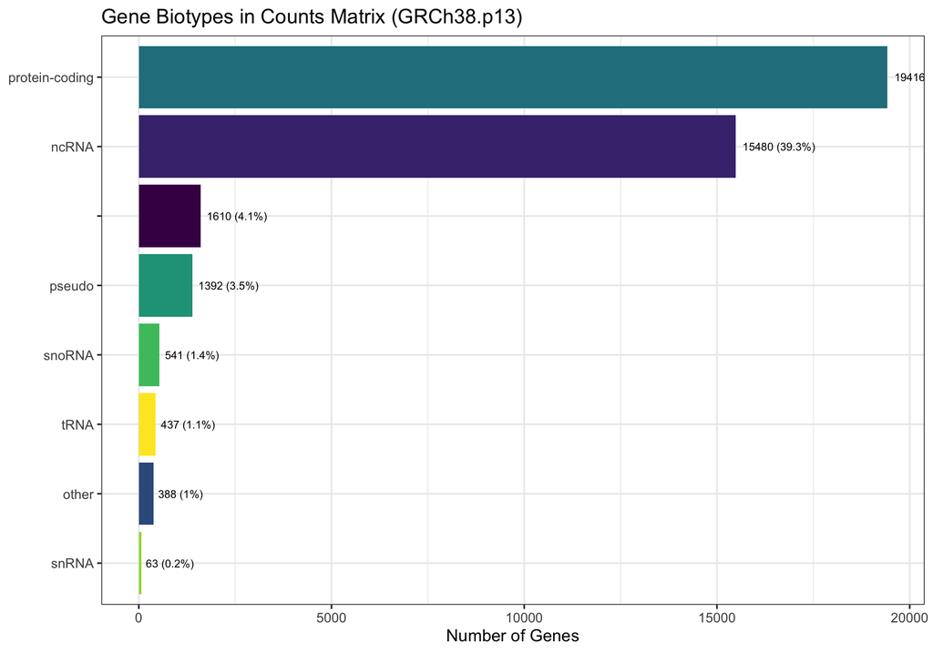

```r
gene_annot_matched <- gene_annot %>%
  dplyr::filter(GeneID %in% as.numeric(rownames(counts)))

biotype_counts <- gene_annot_matched %>%
  dplyr::count(GeneType, sort = TRUE) %>%
  dplyr::mutate(pct = round(100 * n / sum(n), 1))

ggplot(biotype_counts %>% dplyr::filter(n > 50),
       aes(x = reorder(GeneType, n), y = n, fill = GeneType)) +
  geom_col(show.legend = FALSE) +
  geom_text(aes(label = paste0(n, " (", pct, "%)")), hjust = -0.1, size = 3) +
  coord_flip() +
  labs(title = "Gene Biotypes in Counts Matrix (GRCh38.p13)",
       x = NULL, y = "Number of Genes") +
  scale_fill_viridis_d()
```

About half the genes are **protein-coding** (~49%). The rest are non-coding RNA, pseudogenes, etc. Protein-coding genes carry the strongest biological signal for differential expression. After filtering (Section 6), the protein-coding proportion will increase because non-coding genes tend to have very low counts.

# 4. Sample-Level Quality Control

*Ref: Thomas’s book Ch. 7.2*

## 4.1 Library Sizes

Library size = total mapped reads per sample. Large variation means different sequencing depths, which must be normalised.

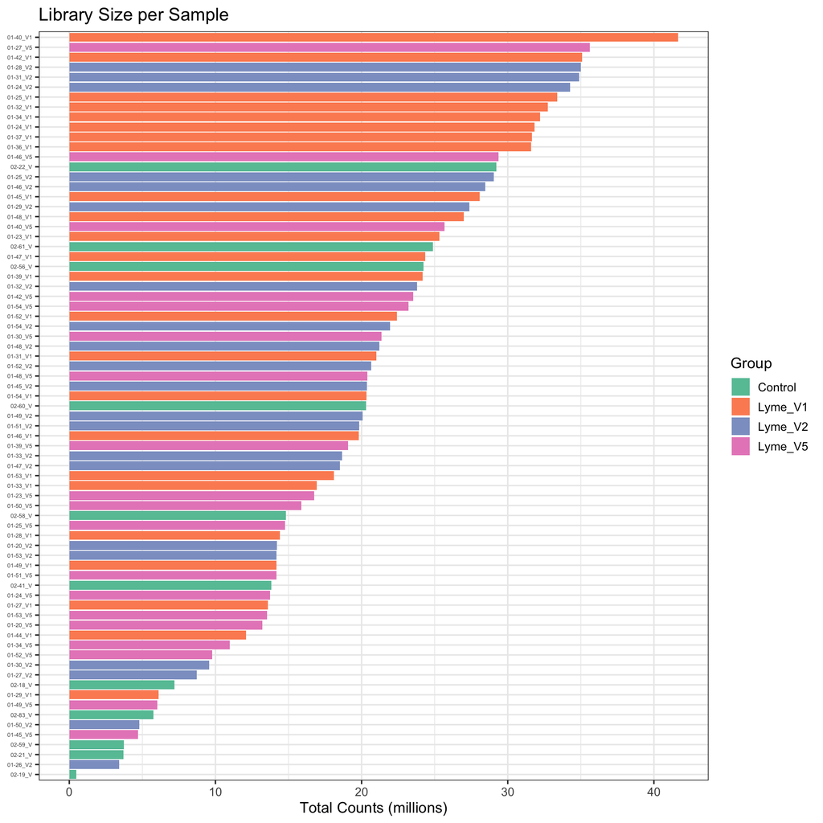

```r
lib_sizes <- data.frame(
  GSM = colnames(counts), total = colSums(counts)
) %>%
  dplyr::left_join(annot %>% dplyr::select(GSM, group, Observation), by = "GSM")

ggplot(lib_sizes, aes(x = reorder(Observation, total),
                       y = total / 1e6, fill = group)) +
  geom_col() + coord_flip() +
  scale_fill_brewer(palette = "Set2") +
  labs(title = "Library Size per Sample",
       x = NULL, y = "Total Counts (millions)", fill = "Group") +
  theme(axis.text.y = element_text(size = 5))
```

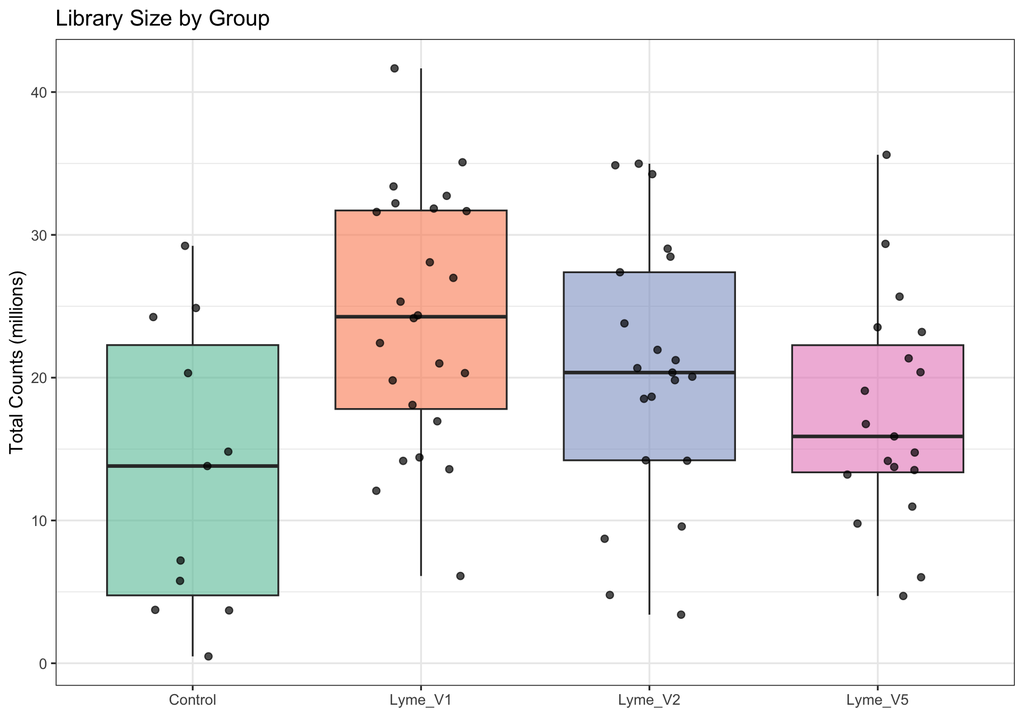

```r
ggplot(lib_sizes, aes(x = group, y = total / 1e6, fill = group)) +
  geom_boxplot(alpha = 0.6, outlier.shape = NA) +
  geom_jitter(width = 0.2, size = 2, alpha = 0.7) +
  scale_fill_brewer(palette = "Set2") +
  labs(title = "Library Size by Group", x = NULL, y = "Total Counts (millions)") +
  theme(legend.position = "none")
```

### How extreme is the library-size imbalance, and is it addressed?

The bar plot looks visually dramatic, so we quantify it: we report the **fold-range** (max / min library size) and the **coefficient of variation (CV = SD / mean)**. A CV > 0.5 or a fold-range > 5 would be a red flag for naive between-sample comparison (e.g. raw FPKM-style normalisation of the 2016 paper). DESeq2’s median-of-ratios method, however, is **robust** to this kind of imbalance because it estimates per-sample size factors from the geometric mean of gene-wise ratios and not from total counts.

```r
lib_summary <- lib_sizes %>%
  dplyr::summarise(
    n           = dplyr::n(),
    min_M       = round(min(total) / 1e6, 1),
    median_M    = round(median(total) / 1e6, 1),
    max_M       = round(max(total) / 1e6, 1),
    fold_range  = round(max(total) / min(total), 2),
    CV          = round(sd(total) / mean(total), 3)
  )
print(lib_summary)
```

```
##    n min_M median_M max_M fold_range    CV
## 1 75   0.5     20.3  41.7      86.65 0.474
```

If a single sample looked like a strong outlier (e.g. > 3× median library size *and* a wildly different RLE in 4.3), we would consider dropping it. Otherwise, the model handles depth differences correctly.

## 4.2 Detected Genes per Sample

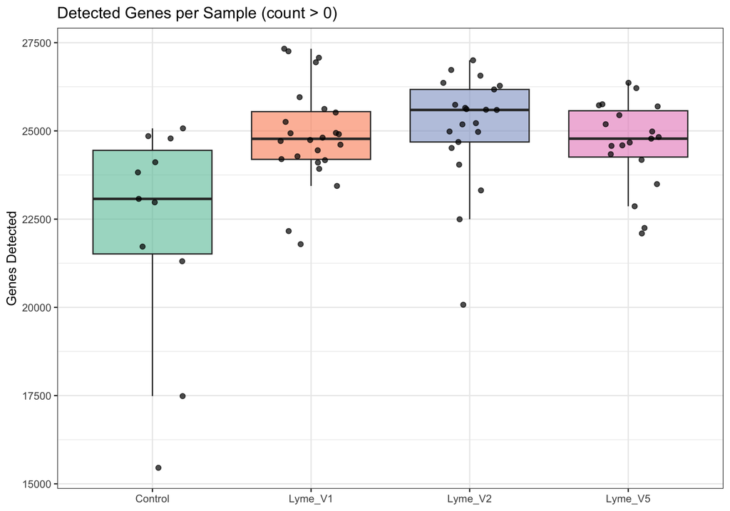

```r
detected <- data.frame(
  GSM = colnames(counts), n_detected = colSums(counts > 0)
) %>%
  dplyr::left_join(annot %>% dplyr::select(GSM, group), by = "GSM")

ggplot(detected, aes(x = group, y = n_detected, fill = group)) +
  geom_boxplot(alpha = 0.6, outlier.shape = NA) +
  geom_jitter(width = 0.2, size = 2, alpha = 0.7) +
  scale_fill_brewer(palette = "Set2") +
  labs(title = "Detected Genes per Sample (count > 0)",
       x = NULL, y = "Genes Detected") +
  theme(legend.position = "none")
```

## 4.3 Relative Log Expression (RLE)

*Ref: Thomas’s book Ch. 7.2.4*

RLE measures how much each gene in a sample deviates from its median expression across all samples. Well-behaved samples centre around zero. Samples with shifted or wide RLE distributions may indicate technical problems or batch effects.

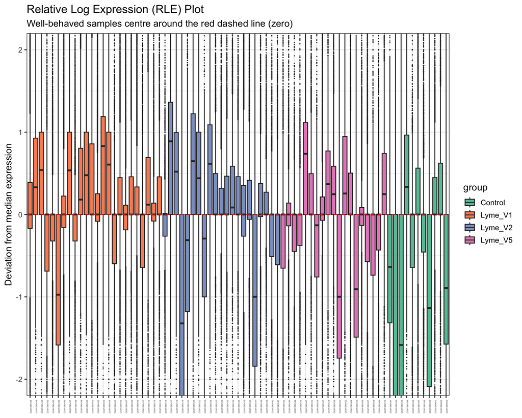

```r
# Compute RLE: for each gene, subtract the row median
log2_counts <- log2(counts + 1)
row_medians <- rowMedians(as.matrix(log2_counts))
rle_matrix  <- sweep(log2_counts, 1, row_medians)

rle_long <- rle_matrix %>%
  as.data.frame() %>%
  tidyr::pivot_longer(everything(), names_to = "GSM", values_to = "RLE") %>%
  dplyr::left_join(annot %>% dplyr::select(GSM, group), by = "GSM")

ggplot(rle_long, aes(x = GSM, y = RLE, fill = group)) +
  geom_boxplot(outlier.size = 0.1) +
  scale_fill_brewer(palette = "Set2") +
  geom_hline(yintercept = 0, linetype = "dashed", color = "red") +
  labs(title = "Relative Log Expression (RLE) Plot",
       subtitle = "Well-behaved samples centre around the red dashed line (zero)",
       x = NULL, y = "Deviation from median expression") +
  theme(axis.text.x = element_text(angle = 90, hjust = 1, size = 3)) +
  coord_cartesian(ylim = c(-2, 2))
```

**Bingo:** Samples with medians shifted away from zero or with unusually wide boxes may have quality issues. If all groups looked similar, there wouldn’t be strong batch effect in the raw data. But apparently, they don’t, so there could be, supporting our hypothesis that there could be batch effects.

# 5. Expression Distributions

## 5.1 Per-Sample Density

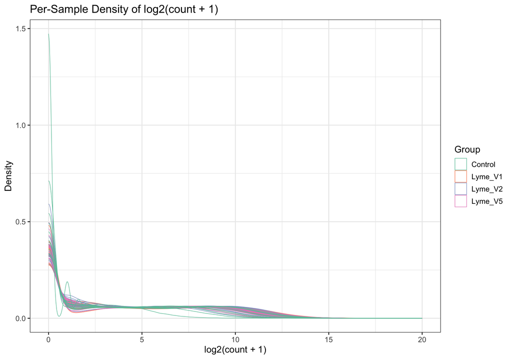

```r
log2_long <- log2_counts %>%
  as.data.frame() %>%
  tibble::rownames_to_column("gene") %>%
  tidyr::pivot_longer(-gene, names_to = "GSM", values_to = "log2_count") %>%
  dplyr::left_join(annot %>% dplyr::select(GSM, group), by = "GSM")

ggplot(log2_long, aes(x = log2_count, group = GSM, color = group)) +
  geom_density(linewidth = 0.3) +
  scale_color_brewer(palette = "Set2") +
  labs(title = "Per-Sample Density of log2(count + 1)",
       x = "log2(count + 1)", y = "Density", color = "Group") +
  xlim(0, 20)
```

the large spike near zero represents the many genes with zero or very low expression. Most of them are still there because we haven’t filtered out the garbage yet. The second hump (should be around 5-10) represents actively expressed genes. What we are looking for looks flat because the scale is zoomed out to accommodate the zero spike. All samples should have a similar shape: if one looks radically different, it may be a quality outlier. Perhaps, we should make a similar plot after filtering.

## 5.2 Mean-Variance Relationship

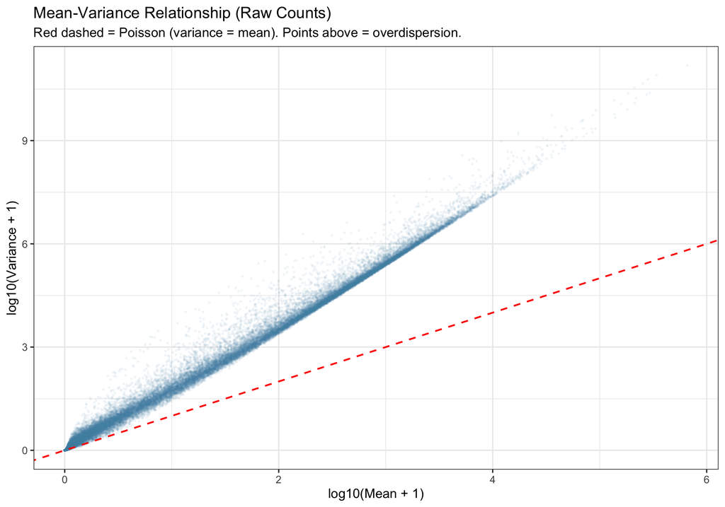

```r
gene_stats <- data.frame(
  mean_count = rowMeans(counts), var_count = apply(counts, 1, var)
)

ggplot(gene_stats, aes(x = log10(mean_count + 1), y = log10(var_count + 1))) +
  geom_point(alpha = 0.05, size = 0.5, color = "steelblue") +
  geom_abline(slope = 1, intercept = 0, color = "red",
              linetype = "dashed", linewidth = 0.8) +
  labs(title = "Mean-Variance Relationship (Raw Counts)",
       subtitle = "Red dashed = Poisson (variance = mean). Points above = overdispersion.",
       x = "log10(Mean + 1)", y = "log10(Variance + 1)")
```

Nearly all genes sit above the red line, meaning variance > mean **if my mean is set correctly**. This overdispersion is exactly why DESeq2 uses a negative binomial model instead of a simpler Poisson model. A Poisson model would dramatically underestimate variability and produce too many false positives.

## 5.3 MA Plot (pre-normalisation)

*Ref: Thomas’s book Ch. 7.2.7*

An MA plot shows each gene’s **average expression** (A) vs. its **log fold change** (M) between two conditions. Before normalisation, the cloud should centre around M=0 (most genes are not differentially expressed). A shift or banana shape indicates a normalisation problem.

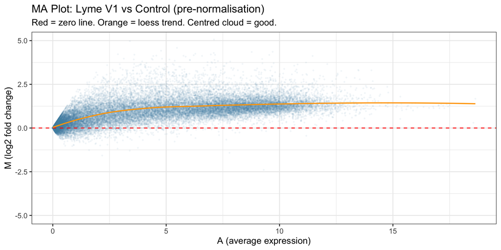

```r
# Quick MA: V1 (first patient) vs first Control
ctrl_cols  <- annot$GSM[annot$group == "Control"]
lyme_cols  <- annot$GSM[annot$group == "Lyme_V1"]

A <- 0.5 * (rowMeans(log2_counts[, ctrl_cols]) + rowMeans(log2_counts[, lyme_cols]))
M <- rowMeans(log2_counts[, lyme_cols]) - rowMeans(log2_counts[, ctrl_cols])

ma_df <- data.frame(A = A, M = M)

ggplot(ma_df, aes(x = A, y = M)) +
  geom_point(alpha = 0.05, size = 0.5, color = "steelblue") +
  geom_hline(yintercept = 0, color = "red", linetype = "dashed") +
  geom_smooth(method = "loess", color = "orange", se = FALSE, linewidth = 0.8) +
  labs(title = "MA Plot: Lyme V1 vs Control (pre-normalisation)",
       subtitle = "Red = zero line. Orange = loess trend. Centred cloud = good.",
       x = "A (average expression)", y = "M (log2 fold change)") +
  coord_cartesian(ylim = c(-5, 5))
```

Cloud isn’t centered around 0, indicating a scaling issue.

# 6. Gene Filtering

We remove genes with very low counts to reduce noise. We require at least N samples (= smallest group size) to have a count >= 10.

```r
smallest_group <- min(table(annot$group))
keep <- rowSums(counts >= 10) >= smallest_group
counts_filtered <- counts[keep, ]

cat("Before:", nrow(counts), "genes\n")
```

```
## Before: 39376 genes
```

```r
cat("After: ", nrow(counts_filtered), "genes\n")
```

```
## After:  20374 genes
```

```r
cat("Removed:", nrow(counts) - nrow(counts_filtered),
    "(", round(100 * (1 - nrow(counts_filtered)/nrow(counts)), 1), "%)\n")
```

```
## Removed: 19002 ( 48.3 %)
```

```r
biotype_after <- gene_annot %>%
  dplyr::filter(GeneID %in% as.numeric(rownames(counts_filtered))) %>%
  dplyr::count(GeneType, sort = TRUE) %>%
  dplyr::mutate(pct = round(100 * n / sum(n), 1))
print(biotype_after)
```

```
##          GeneType     n  pct
## 1  protein-coding 14378 70.6
## 2           ncRNA  4000 19.6
## 3                   703  3.5
## 4          pseudo   693  3.4
## 5           other   301  1.5
## 6          snoRNA   206  1.0
## 7            tRNA    41  0.2
## 8           snRNA    23  0.1
## 9            rRNA    22  0.1
## 10          scRNA     4  0.0
## 11        unknown     3  0.0
```

**Meaning:** After aggressive filtering, ~70% of remaining genes are **protein-coding** (up from ~49%), confirming that most low-count genes were non-coding RNA and pseudogenes. This is expected and desirable.

# 7. DESeq2 Normalisation

*Ref: Thomas’s book Ch. 7.6e*

## 7.1 Create DESeqDataSet

The `design = ~ group` formula tells DESeq2 to model expression as a function of our four experimental groups.

```r
dds <- DESeqDataSetFromMatrix(
  countData = counts_filtered, colData = annot, design = ~ group)
```

## 7.2 Size Factors

DESeq2 estimates a **size factor** per sample via the median-of-ratios method (Anders & Huber 2010). This **directly addresses the library-size imbalance flagged in Section 4.1**: each sample’s counts are divided by its size factor before any statistical test, so a sample sequenced 3× deeper than another is not falsely flagged as having “more expression”. This is far superior to the FPKM normalisation used in the original 2016 study, which only corrects for length and depth without controlling for sample composition.

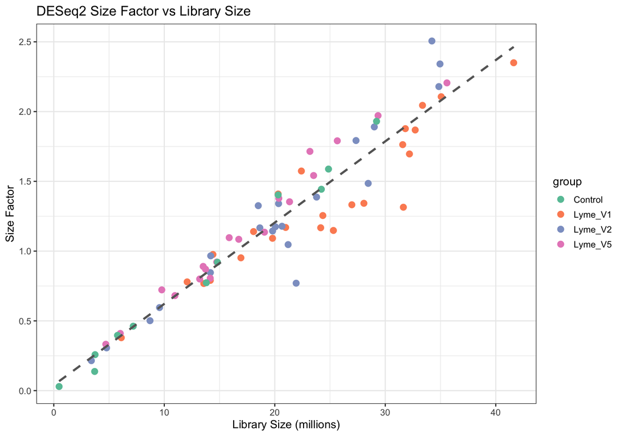

```r
dds <- estimateSizeFactors(dds)

sf_df <- data.frame(
  GSM = colnames(dds), size_factor = sizeFactors(dds),
  lib_size = colSums(counts_filtered)
) %>%
  dplyr::left_join(annot %>% dplyr::select(GSM, group), by = "GSM")

ggplot(sf_df, aes(x = lib_size / 1e6, y = size_factor, color = group)) +
  geom_point(size = 3) +
  geom_smooth(method = "lm", se = FALSE, color = "gray40", linetype = "dashed") +
  scale_color_brewer(palette = "Set2") +
  labs(title = "DESeq2 Size Factor vs Library Size",
       x = "Library Size (millions)", y = "Size Factor")
```

```r
cat("Size factor range: ", round(range(sizeFactors(dds)), 3),
    " (fold:", round(max(sizeFactors(dds)) / min(sizeFactors(dds)), 2), ")\n")
```

```
## Size factor range:  0.029 2.506  (fold: 85.11 )
```

## 7.3 MA Plot (after size-factor normalization)

*Ref: Thomas’s book Ch. 7.2.7*

Once **size factors** are applied, `counts(dds, normalized = TRUE)` is on a comparable scale across samples. We pool Lyme V1 vs Control and plot **M** = log2 ratio of group means vs **A** = average log2 signal (same construction as Section 5.3, but using median-of-ratios normalized counts). The loess trend should sit near **M = 0** across most expression levels if depth correction worked; a strong banana or vertical offset would suggest residual technical bias (or real biology concentrated at certain expression ranges).

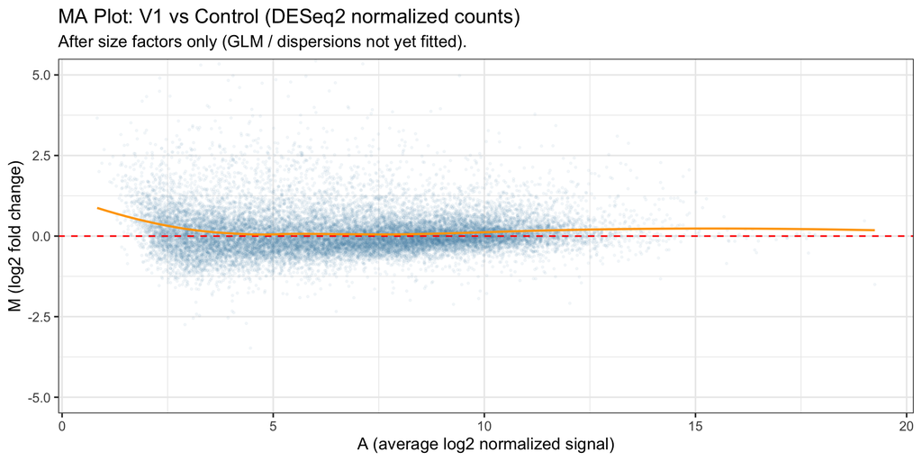

```r
nt <- counts(dds, normalized = TRUE)
ctrl_cols <- annot$GSM[annot$group == "Control"]
v1_cols   <- annot$GSM[annot$group == "Lyme_V1"]

m1 <- rowMeans(nt[, v1_cols, drop = FALSE])
m0 <- rowMeans(nt[, ctrl_cols, drop = FALSE])
A_norm <- 0.5 * (log2(m1 + 0.5) + log2(m0 + 0.5))
M_norm <- log2((m1 + 0.5) / (m0 + 0.5))

ggplot(data.frame(A = A_norm, M = M_norm), aes(x = A, y = M)) +
  geom_point(alpha = 0.05, size = 0.5, color = "steelblue") +
  geom_hline(yintercept = 0, color = "red", linetype = "dashed") +
  geom_smooth(method = "loess", color = "orange", se = FALSE, linewidth = 0.8) +
  labs(title = "MA Plot: V1 vs Control (DESeq2 normalized counts)",
       subtitle = "After size factors only (GLM / dispersions not yet fitted).",
       x = "A (average log2 normalized signal)", y = "M (log2 fold change)") +
  coord_cartesian(ylim = c(-5, 5))
```

Compare with the pre-normalisation MA (Section 5.3): the cloud should be **more tightly centred** on M = 0 after size factors. A later **DESeq2 `plotMA()`** after the full model (Section 10.1) adds dispersion shrinkage and hypothesis testing; that plot is the standard check bundled with DESeq2.

## 7.4 Variance Stabilising Transformation (VST)

Raw counts have a mean-variance dependency (Section 5.2). VST produces values on a log2-like scale with approximately **constant variance**, suitable for PCA and heatmaps.

```r
vsd <- vst(dds, blind = FALSE)
```

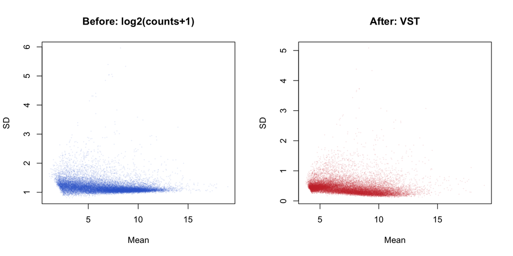

```r
par(mfrow = c(1, 2))
plot(rowMeans(log2(counts_filtered + 1)),
     apply(log2(counts_filtered + 1), 1, sd),
     pch = 16, cex = 0.3, col = rgb(0.2, 0.4, 0.8, 0.1),
     xlab = "Mean", ylab = "SD", main = "Before: log2(counts+1)")
plot(rowMeans(assay(vsd)), apply(assay(vsd), 1, sd),
     pch = 16, cex = 0.3, col = rgb(0.8, 0.2, 0.2, 0.1),
     xlab = "Mean", ylab = "SD", main = "After: VST")
```

```r
par(mfrow = c(1, 1))
```

Before VST (left), low-expression genes have variable SD. After VST (right), the trend should be flattened, but it’s not, so the SD still depends on the mean. This makes the meaningfullness of distances between samples (for PCA, clustering) questionable.

The following quantifies the mean–SD coupling before vs after VST so we don’t have to read it off the eye.

```r
mean_sd_before <- cor(
  rowMeans(log2(counts_filtered + 1)),
  apply(log2(counts_filtered + 1), 1, sd)
)
mean_sd_after <- cor(
  rowMeans(assay(vsd)),
  apply(assay(vsd), 1, sd)
)

cat("Mean-SD correlation BEFORE VST (log2(counts+1)) :",
    round(mean_sd_before, 3), "\n")
```

```
## Mean-SD correlation BEFORE VST (log2(counts+1)) : -0.245
```

```r
cat("Mean-SD correlation AFTER  VST                  :",
    round(mean_sd_after,  3), "\n")
```

```
## Mean-SD correlation AFTER  VST                  : -0.209
```

```r
cat("Reduction (closer to zero is better)            :",
    round(mean_sd_before - mean_sd_after, 3), "\n")
```

```
## Reduction (closer to zero is better)            : -0.036
```

```r
if (mean_sd_after < mean_sd_before) {
  cat("VST DID reduce mean-variance coupling — usable for PCA / heatmaps.\n")
} else {
  cat("VST did NOT reduce mean-variance coupling — investigate (try rlog or check for outlier samples).\n")
}
```

```
## VST did NOT reduce mean-variance coupling — investigate (try rlog or check for outlier samples).
```

A **positive** reduction (before − after > 0) means VST did its job. A typical drop is from ~0.7–0.9 (raw log2) to ~0.2–0.5 (after VST); the residual coupling is normal, VST is an approximation, not a guarantee of zero correlation. Confirm with Thomas if the reduction is small (<0.1) or if VST made things worse, in which case `rlog()` may be preferable for this dataset.

# 8. PCA

*Ref: Thomas’s book Ch. 7.2.2*

```r
rv      <- rowVars(assay(vsd))
top_idx <- order(rv, decreasing = TRUE)[1:min(2000, length(rv))]

pca     <- prcomp(t(assay(vsd)[top_idx, ]), center = TRUE, scale. = TRUE)
var_pct <- round(100 * summary(pca)$importance[2, ], 1)

pca_df  <- data.frame(pca$x[, 1:5]) %>%
  tibble::rownames_to_column("GSM") %>%
  dplyr::left_join(annot, by = "GSM")
```

## 8.1 Scree Plot

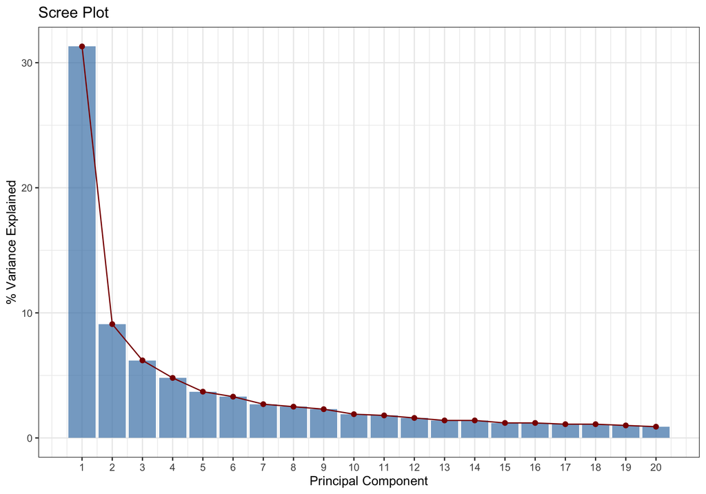

```r
ggplot(data.frame(PC = 1:20, Var = var_pct[1:20]),
       aes(x = PC, y = Var)) +
  geom_col(fill = "steelblue", alpha = 0.7) +
  geom_line(color = "darkred") + geom_point(color = "darkred", size = 2) +
  labs(title = "Scree Plot", x = "Principal Component",
       y = "% Variance Explained") +
  scale_x_continuous(breaks = 1:20)
```

## 8.2 PCA by Group

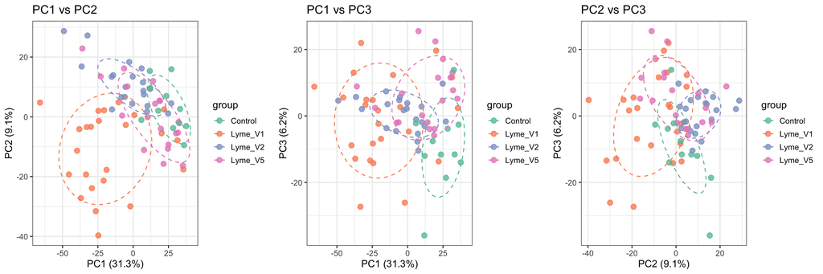

```r
make_pca <- function(df, pcx, pcy, vpct) {
  ggplot(df, aes(x = .data[[pcx]], y = .data[[pcy]], color = group)) +
    geom_point(size = 3, alpha = 0.8) +
    stat_ellipse(level = 0.68, linetype = "dashed") +
    scale_color_brewer(palette = "Set2") +
    labs(x = paste0(pcx, " (", vpct[as.integer(gsub("PC","",pcx))], "%)"),
         y = paste0(pcy, " (", vpct[as.integer(gsub("PC","",pcy))], "%)"))
}

grid.arrange(
  make_pca(pca_df,"PC1","PC2",var_pct) + ggtitle("PC1 vs PC2"),
  make_pca(pca_df,"PC1","PC3",var_pct) + ggtitle("PC1 vs PC3"),
  make_pca(pca_df,"PC2","PC3",var_pct) + ggtitle("PC2 vs PC3"),
  ncol = 3
)
```

## 8.3 Patient Trajectories

Lines connect the same patient across V1 -> V2 -> V5.

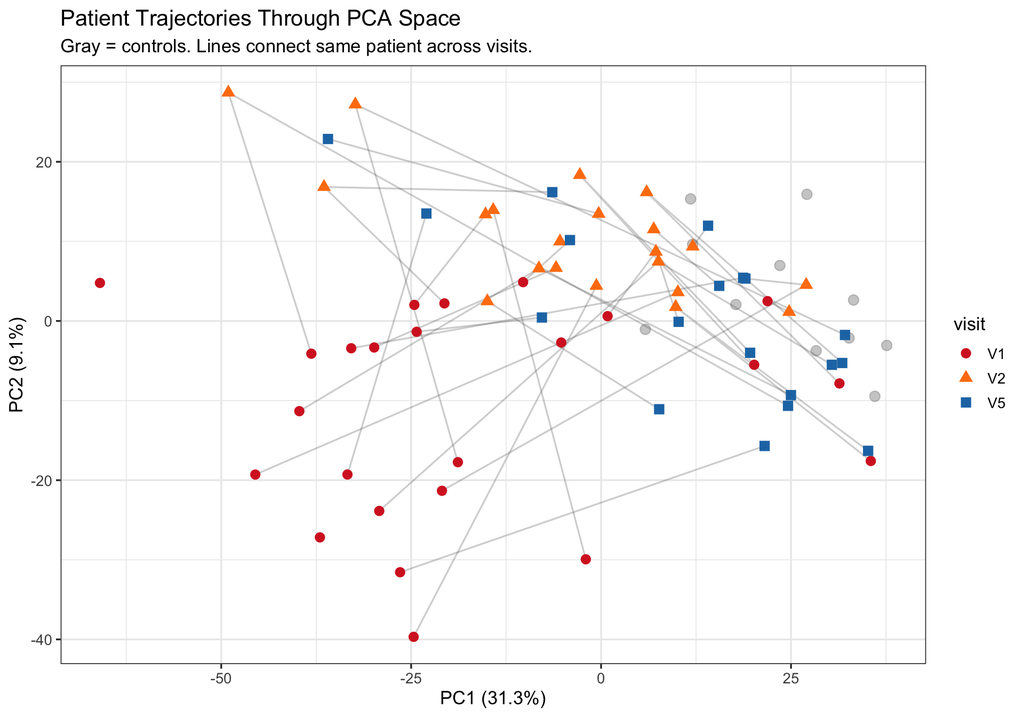

```r
lyme_pca <- pca_df %>% dplyr::filter(condition == "Lyme") %>%
  dplyr::arrange(patient_id, visit)

ggplot() +
  geom_point(data = pca_df %>% dplyr::filter(condition == "Control"),
             aes(x = PC1, y = PC2), color = "gray60", size = 3, alpha = 0.5) +
  geom_path(data = lyme_pca,
            aes(x = PC1, y = PC2, group = patient_id),
            color = "gray40", alpha = 0.3) +
  geom_point(data = lyme_pca,
             aes(x = PC1, y = PC2, color = visit, shape = visit), size = 3) +
  scale_color_manual(values = c(V1="#d62728", V2="#ff7f0e", V5="#1f77b4")) +
  labs(title = "Patient Trajectories Through PCA Space",
       subtitle = "Gray = controls. Lines connect same patient across visits.",
       x = paste0("PC1 (", var_pct[1], "%)"),
       y = paste0("PC2 (", var_pct[2], "%)"))
```

Each line represents one patient’s journey from acute infection (red V1) through treatment (orange V2) to 6-month follow-up (blue V5). Reassuringly, most V5 points move toward the gray control cloud, showing recovery. Patients whose V5 stays far from controls are the ones to worry about, they are likely candidates for **post-treatment Lyme disease syndrome (PTLDS)**.

# 9. Sample Relationships

*Ref: Thomas’s book Ch. 7.2.1*

## 9.1 Distance Heatmap

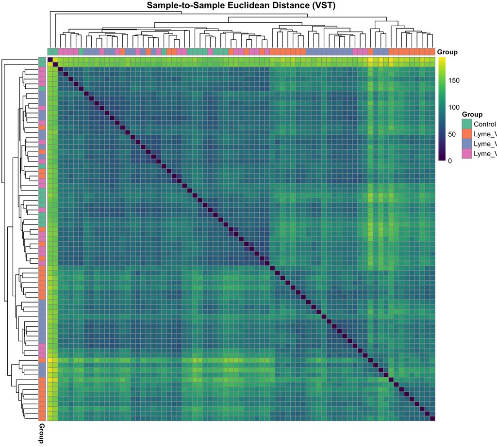

```r
sample_dists <- dist(t(assay(vsd)))
row_annot <- data.frame(Group = annot$group, row.names = annot$GSM)
ann_colors <- list(Group = c(Control="#66C2A5", Lyme_V1="#FC8D62",
                              Lyme_V2="#8DA0CB", Lyme_V5="#E78AC3"))

pheatmap(as.matrix(sample_dists),
         clustering_distance_rows = sample_dists,
         clustering_distance_cols = sample_dists,
         annotation_row = row_annot, annotation_col = row_annot,
         annotation_colors = ann_colors,
         show_rownames = FALSE, show_colnames = FALSE,
         color = viridis(100),
         main = "Sample-to-Sample Euclidean Distance (VST)")
```

## 9.2 Top 50 Most Variable Genes

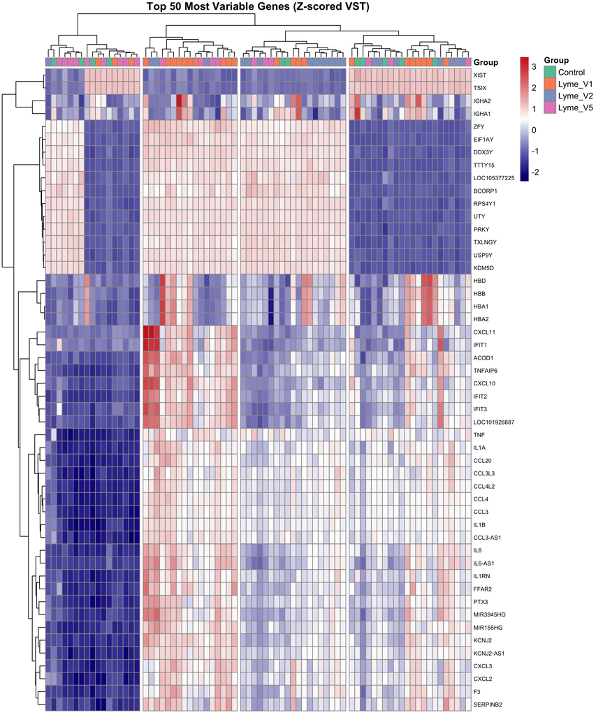

```r
top50_idx <- head(order(rv, decreasing = TRUE), 50)
top50_ids <- rownames(assay(vsd))[top50_idx]
top50_sym <- gene_annot$Symbol[match(as.numeric(top50_ids), gene_annot$GeneID)]
top50_lab <- ifelse(is.na(top50_sym) | top50_sym == "", top50_ids, top50_sym)

hm_mat <- assay(vsd)[top50_idx, ]
rownames(hm_mat) <- top50_lab

pheatmap(t(scale(t(hm_mat))),
         annotation_col = row_annot, annotation_colors = ann_colors,
         show_colnames = FALSE, fontsize_row = 7,
         color = colorRampPalette(c("navy","white","firebrick3"))(100),
         main = "Top 50 Most Variable Genes (Z-scored VST)",
         cutree_cols = 4)
```

Rows are genes, columns are samples. Red = high expression, blue = low expression (relative to the gene’s mean). If the heatmap clusters samples by group (check the colour bar at top), it confirms that the dominant source of variation is biological (disease state / time point), not technical noise.

# 10. Differential Expression with DESeq2

*Ref: Thomas’s book Ch. 7.6*

## 10.1 Run DESeq2

```r
dds <- DESeq(dds)
resultsNames(dds)
```

```
## [1] "Intercept"                "group_Lyme_V1_vs_Control" "group_Lyme_V2_vs_Control" "group_Lyme_V5_vs_Control"
```

## 10.1a Dispersion estimates (*quantifying how variant the dataset is*)

The single best diagnostic for “is this dataset noisy?” is the **dispersion plot**. DESeq2 fits a gene-wise dispersion (black dots), shrinks each estimate towards a fitted trend (red curve), and uses the shrunken values (blue) for testing. The y-axis is the **dispersion parameter α** of the negative binomial, which captures biological + technical variability *beyond* Poisson noise.

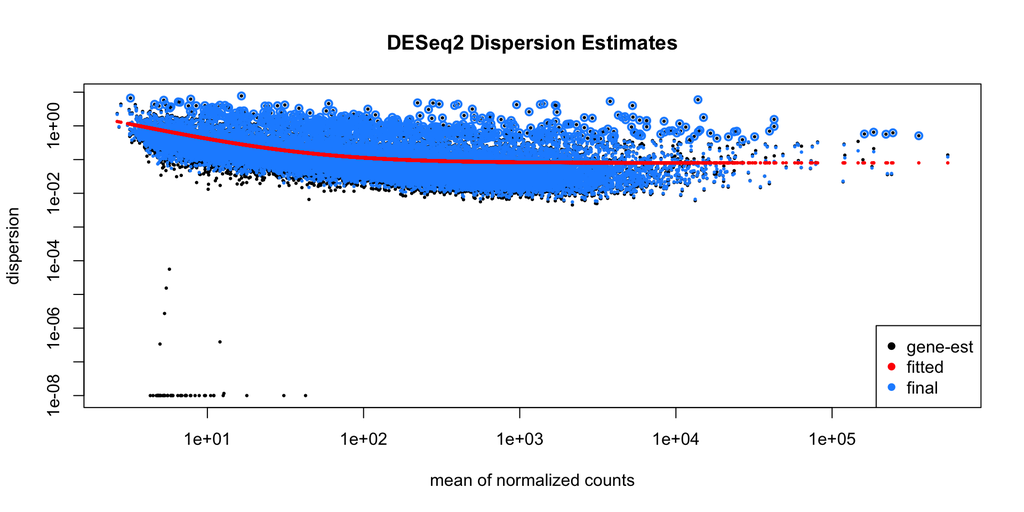

```r
plotDispEsts(dds, main = "DESeq2 Dispersion Estimates")
```

- The fitted (red) trend should slope **down** as expression increases, then flatten, that is the textbook shape and indicates the model assumptions hold.
- If many gene-wise dots sit **far above** the fitted line, the dataset is **highly variable** (lots of biological / between-patient noise). For our Lyme cohort this is expected: patients are sampled at different disease stages, with heterogeneous immune trajectories, and individual variation in the inflammatory response is well known. A median dispersion of ~0.05–0.1 is typical for clean cell-line RNA-seq; values of ~0.2–0.5 are typical for human PBMC studies like this one.
- Genes flagged as outliers (circled) are pulled down to the fitted curve by `lfcShrink()` (Section 10.2), which is precisely why we use shrunken LFCs.

```r
disp <- dispersions(dds)
cat("Dispersion summary across", length(disp), "genes:\n")
```

```
## Dispersion summary across 20374 genes:
```

```r
print(summary(disp))
```

```
##     Min.  1st Qu.   Median     Mean  3rd Qu.     Max.
## 0.005535 0.042004 0.092187 0.198871 0.225087 7.722985
```

```r
cat("\nMedian dispersion:", round(median(disp, na.rm = TRUE), 3),
    "  (PBMC studies typically 0.1–0.5)\n")
```

```
##
## Median dispersion: 0.092   (PBMC studies typically 0.1–0.5)
```

## 10.1b MA plots (DESeq2: normalized mean vs LFC)

After `DESeq()`, the object contains fitted dispersions and contrasts on the **same scale** as differential testing. `plotMA()` shows, for each gene, the **mean of normalized counts** (x-axis, “mean of normalized counts”) vs **log2 fold change** (y-axis); points with padj below `alpha` are blue. For a successful normalization and contrast, the **bulk of points** should scatter around **LFC = 0** at moderate-to-high expression, with no strong systematic curve. These plots complement Section 7.3 (MA from normalized counts only) and Section 5.3 (raw log2 counts).

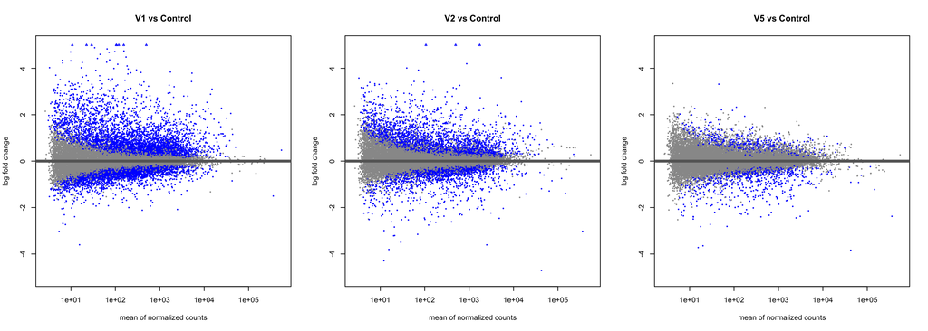

```r
par(mfrow = c(1, 3))
plotMA(
  results(dds, contrast = c("group", "Lyme_V1", "Control"), alpha = 0.05),
  main = "V1 vs Control", ylim = c(-5, 5))
plotMA(
  results(dds, contrast = c("group", "Lyme_V2", "Control"), alpha = 0.05),
  main = "V2 vs Control", ylim = c(-5, 5))
plotMA(
  results(dds, contrast = c("group", "Lyme_V5", "Control"), alpha = 0.05),
  main = "V5 vs Control", ylim = c(-5, 5))
```

```r
par(mfrow = c(1, 1))
```

**Result validation:** If the cloud were systematically shifted away from LFC = 0 for most genes, we would revisit size factors, outliers, or design formula. Here the **MA after normalization** (Section 7.3) and these **MA after the full DESeq2 fit** together support using the contrasts for pathway analysis.

## 10.2 Extract, Shrink & Annotate Results

`lfcShrink()` with `ashr` produces moderated log2 fold-change estimates that are more reliable for genes with low counts. *(Stephens 2016)*

```r
contrasts <- list(
  V1 = c("group", "Lyme_V1", "Control"),
  V2 = c("group", "Lyme_V2", "Control"),
  V5 = c("group", "Lyme_V5", "Control")
)

get_annotated_results <- function(dds, contrast, gene_annot) {
  res <- results(dds, contrast = contrast, alpha = 0.05)
  res_shrunk <- lfcShrink(dds, contrast = contrast, type = "ashr", res = res)

  as.data.frame(res_shrunk) %>%
    tibble::rownames_to_column("GeneID") %>%
    dplyr::mutate(GeneID_num = as.numeric(GeneID)) %>%
    dplyr::left_join(
      gene_annot %>% dplyr::select(GeneID, Symbol, Description, GeneType),
      by = c("GeneID_num" = "GeneID")) %>%
    dplyr::select(-GeneID_num) %>%
    dplyr::arrange(padj)
}

res_list <- lapply(contrasts, function(ct)
  get_annotated_results(dds, ct, gene_annot))
```

## 10.3 DEG Summary

```r
deg_summary <- lapply(names(res_list), function(nm) {
  sig <- res_list[[nm]] %>%
    dplyr::filter(!is.na(padj) & padj < 0.05 & abs(log2FoldChange) > 1)
  data.frame(Comparison = paste0(nm, " vs Control"),
             Total = nrow(sig),
             Up = sum(sig$log2FoldChange > 0),
             Down = sum(sig$log2FoldChange < 0))
}) %>% dplyr::bind_rows()

print(deg_summary)
```

```
##      Comparison Total  Up Down
## 1 V1 vs Control  1020 918  102
## 2 V2 vs Control   549 367  182
## 3 V5 vs Control   125  14  111
```

Compare with the original study (Limma/Voom on FPKM): V1=1,235, V2=1,060, V5=686 DEGs. Not a 100% sure why our numbers differ, but I assume it’s because we use:

1. a different genome reference
2. raw counts instead of FPKM
3. DESeq2 instead of Limma/Voom, and (4) different fold-change/FDR thresholds.

The pattern should be similar: most DEGs at V1 (acute), declining through V2 and V5 as the transcriptome partially recovers.

## 10.4 Top DEGs across all time points

We list the top 15 DEGs at each visit (acute V1, post-treatment V2, 6-month follow-up V5) so readers can scan the strongest signals at every stage of the disease trajectory in one place.

```r
top_degs <- function(df, n = 15) {
  df %>%
    dplyr::filter(!is.na(padj) & padj < 0.05) %>%
    head(n) %>%
    dplyr::select(Symbol, log2FoldChange, padj, GeneType)
}

for (tp in names(res_list)) {
  cat("\n===== Top 15 DEGs at", tp, "vs Control =====\n")
  print(top_degs(res_list[[tp]], 15))
}
```

```
##
## ===== Top 15 DEGs at V1 vs Control =====
##       Symbol log2FoldChange         padj       GeneType
## 1      SYTL1      -1.032377 4.315169e-18 protein-coding
## 2       RRM2       2.955710 4.703122e-16 protein-coding
## 3     S100A9       2.162965 4.059887e-14 protein-coding
## 4      MKI67       2.747149 4.059887e-14 protein-coding
## 5    TP53I13      -1.490550 5.250684e-14 protein-coding
## 6     ALKBH2      -1.706800 9.810895e-14 protein-coding
## 7      RUSF1      -1.002112 1.807917e-13 protein-coding
## 8  LINC01278      -1.636465 2.579987e-13          ncRNA
## 9       ASPM       2.562225 2.857008e-13 protein-coding
## 10   FCGR1CP       4.014715 4.623417e-13         pseudo
## 11     CLSPN       2.558881 5.226567e-13 protein-coding
## 12      CD3D      -1.331106 5.226567e-13 protein-coding
```

[output cut: 39 more lines]

Genes that *only* appear at V5 (rather than carrying over from V1) are typically related to homeostasis / repair and are interesting to flag separately.

## 10.5 Volcano Plots

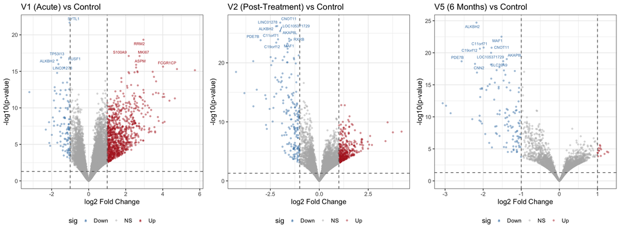

```r
make_volcano <- function(df, title) {
  df <- df %>%
    dplyr::mutate(sig = dplyr::case_when(
      is.na(padj) ~ "NS",
      padj < 0.05 & log2FoldChange > 1  ~ "Up",
      padj < 0.05 & log2FoldChange < -1 ~ "Down",
      TRUE ~ "NS"))
  top <- df %>% dplyr::filter(sig != "NS") %>% head(10)
  ggplot(df, aes(x = log2FoldChange, y = -log10(pvalue), color = sig)) +
    geom_point(alpha = 0.4, size = 1) +
    scale_color_manual(values = c(Up="firebrick", Down="steelblue", NS="gray70")) +
    geom_text_repel(data = top, aes(label = Symbol), size = 2.5,
                    max.overlaps = 15) +
    geom_vline(xintercept = c(-1,1), linetype = "dashed", color = "gray40") +
    geom_hline(yintercept = -log10(0.05), linetype = "dashed", color = "gray40") +
    labs(title = title, x = "log2 Fold Change", y = "-log10(p-value)") +
    theme(legend.position = "bottom")
}

grid.arrange(
  make_volcano(res_list$V1, "V1 (Acute) vs Control"),
  make_volcano(res_list$V2, "V2 (Post-Treatment) vs Control"),
  make_volcano(res_list$V5, "V5 (6 Months) vs Control"),
  ncol = 3
)
```

Each dot is a gene. The x-axis is the fold change (how much the gene changes in Lyme vs. Control). The y-axis is statistical significance. **Red dots** (upper-right) are significantly upregulated, **blue dots** (upper-left) are downregulated.

The labeled genes are the most significant. We can see how the “cloud” narrows from V1 to V5, fewer genes are dramatically changed at 6 months, matching the original paper’s finding of a gradually resolving but sustained signature.

## 10.6 Genes of Interest — picks for the discussion

```r
genes_of_interest <- c("CXCL10", "S100A8", "S100A9", "FCGR1A",
                       "IDO1", "CD274", "TLR2", "IL6",
                       "SERPING1", "ISG15", "IFI27", "BATF2")

goi_df <- res_list$V1 %>%
  dplyr::filter(Symbol %in% genes_of_interest) %>%
  dplyr::select(Symbol, log2FoldChange, padj, baseMean, Description) %>%
  dplyr::arrange(dplyr::desc(log2FoldChange))
print(goi_df)
```

```
##      Symbol log2FoldChange         padj    baseMean                                          Description
## 1     BATF2       3.782273 3.595137e-07    34.19147 basic leucine zipper ATF-like transcription factor 2
## 2      IDO1       3.736749 1.420203e-07    72.11093                        indoleamine 2,3-dioxygenase 1
## 3  SERPING1       3.640064 1.823182e-11   183.74026                             serpin family G member 1
## 4     IFI27       3.584916 4.872386e-06    10.72710                interferon alpha inducible protein 27
## 5    FCGR1A       3.456485 1.447165e-12   377.29945                                 Fc gamma receptor Ia
## 6    CXCL10       2.698305 8.097928e-05  1731.37902                      C-X-C motif chemokine ligand 10
## 7     CD274       2.331941 9.205980e-06   393.82967                                       CD274 molecule
## 8    S100A9       2.162965 4.059887e-14 12517.70744                      S100 calcium binding protein A9
## 9    S100A8       2.152880 1.447165e-12  5278.99261                      S100 calcium binding protein A8
## 10    ISG15       2.086229 3.044554e-05   288.76371                        ISG15 ubiquitin like modifier
## 11      IL6       1.712365 1.588639e-03  4277.73837                                        interleukin 6
## 12     TLR2       1.476232 6.147265e-08  3527.23591                                 toll like receptor 2
```

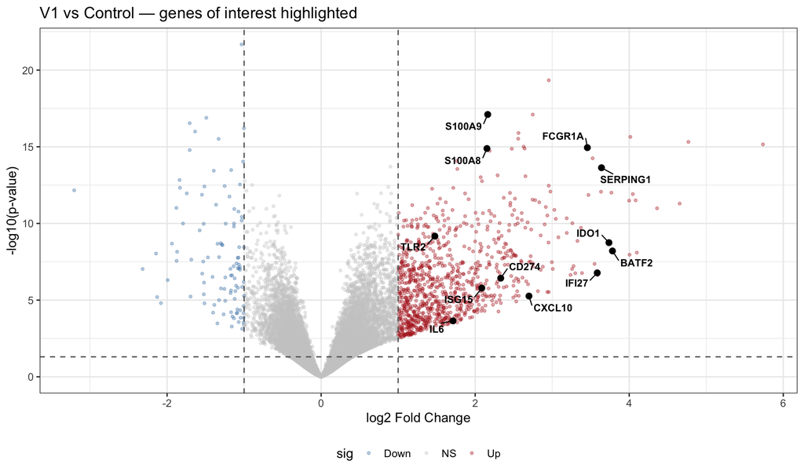

```r
make_volcano_highlight <- function(df, title, highlight) {
  df <- df %>%
    dplyr::mutate(sig = dplyr::case_when(
      is.na(padj) ~ "NS",
      padj < 0.05 & log2FoldChange > 1  ~ "Up",
      padj < 0.05 & log2FoldChange < -1 ~ "Down",
      TRUE ~ "NS"))
  hl <- df %>% dplyr::filter(Symbol %in% highlight)
  ggplot(df, aes(x = log2FoldChange, y = -log10(pvalue))) +
    geom_point(aes(color = sig), alpha = 0.35, size = 1) +
    geom_point(data = hl, color = "black", size = 2.4) +
    geom_text_repel(data = hl, aes(label = Symbol),
                    size = 3.5, fontface = "bold",
                    box.padding = 0.5, max.overlaps = 50) +
    scale_color_manual(values = c(Up="firebrick", Down="steelblue", NS="gray80")) +
    geom_vline(xintercept = c(-1,1), linetype = "dashed", color = "gray40") +
    geom_hline(yintercept = -log10(0.05), linetype = "dashed", color = "gray40") +
    labs(title = title, x = "log2 Fold Change", y = "-log10(p-value)") +
    theme(legend.position = "bottom")
}

make_volcano_highlight(res_list$V1,
                       "V1 vs Control — genes of interest highlighted",
                       genes_of_interest)
```

### V2 vs Control, what survives the antibiotic course?

```r
goi_v2_df <- res_list$V2 %>%
  dplyr::filter(Symbol %in% genes_of_interest) %>%
  dplyr::select(Symbol, log2FoldChange, padj, baseMean, Description) %>%
  dplyr::arrange(dplyr::desc(log2FoldChange))
cat("Genes of interest at V2 (sorted by LFC):\n")
```

```
## Genes of interest at V2 (sorted by LFC):
```

```r
print(goi_v2_df)
```

```
##      Symbol log2FoldChange         padj    baseMean                                          Description
## 1    CXCL10      3.7589306 5.844798e-07  1731.37902                      C-X-C motif chemokine ligand 10
## 2      IDO1      2.6900492 4.032981e-05    72.11093                        indoleamine 2,3-dioxygenase 1
## 3     ISG15      2.1565686 1.211780e-05   288.76371                        ISG15 ubiquitin like modifier
## 4     CD274      1.0828638 5.769795e-03   393.82967                                       CD274 molecule
## 5     BATF2      1.0662002 6.701602e-03    34.19147 basic leucine zipper ATF-like transcription factor 2
## 6    S100A9      1.0121897 2.810252e-04 12517.70744                      S100 calcium binding protein A9
## 7    FCGR1A      0.9868142 6.893303e-03   377.29945                                 Fc gamma receptor Ia
## 8       IL6      0.8508698 1.413947e-02  4277.73837                                        interleukin 6
## 9      TLR2      0.8272417 1.527905e-03  3527.23591                                 toll like receptor 2
## 10   S100A8      0.7421484 5.227257e-03  5278.99261                      S100 calcium binding protein A8
## 11 SERPING1      0.7078827 2.429916e-02   183.74026                             serpin family G member 1
## 12    IFI27      0.5605861 3.188764e-02    10.72710                interferon alpha inducible protein 27
```

```r
goi_still_up_v2 <- goi_v2_df %>%
  dplyr::filter(!is.na(padj) & padj < 0.05 & log2FoldChange > 1) %>%
  dplyr::pull(Symbol)
cat("\nGenes of interest still significantly UP at V2:",
    length(goi_still_up_v2), "/", length(genes_of_interest),
    "->", paste(goi_still_up_v2, collapse = ", "), "\n")
```

```
##
## Genes of interest still significantly UP at V2: 6 / 12 -> CXCL10, IDO1, ISG15, CD274, BATF2, S100A9
```

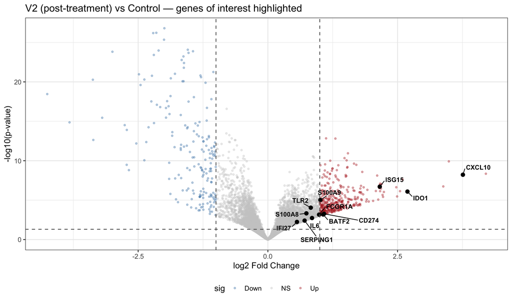

```r
make_volcano_highlight(res_list$V2,
                       "V2 (post-treatment) vs Control — genes of interest highlighted",
                       genes_of_interest)
```

### V5 vs Control, does CXCL10 (and the rest of the V1 picks) survive 6 months later?

```r
goi_v5_df <- res_list$V5 %>%
  dplyr::filter(Symbol %in% genes_of_interest) %>%
  dplyr::select(Symbol, log2FoldChange, padj, baseMean, Description) %>%
  dplyr::arrange(dplyr::desc(log2FoldChange))
cat("Genes of interest at V5 (sorted by LFC):\n")
```

```
## Genes of interest at V5 (sorted by LFC):
```

```r
print(goi_v5_df)
```

```
##      Symbol log2FoldChange        padj    baseMean                                          Description
## 1    S100A9     0.75670267 0.004180443 12517.70744                      S100 calcium binding protein A9
## 2    S100A8     0.52729444 0.025262316  5278.99261                      S100 calcium binding protein A8
## 3    FCGR1A     0.34224618 0.079401846   377.29945                                 Fc gamma receptor Ia
## 4  SERPING1     0.31573079 0.086896682   183.74026                             serpin family G member 1
## 5      TLR2     0.31091647 0.089259063  3527.23591                                 toll like receptor 2
## 6      IDO1     0.17260373 0.169014454    72.11093                        indoleamine 2,3-dioxygenase 1
## 7     BATF2     0.10769943 0.298394742    34.19147 basic leucine zipper ATF-like transcription factor 2
## 8     ISG15     0.09958797 0.412245615   288.76371                        ISG15 ubiquitin like modifier
## 9    CXCL10     0.07692357 0.431486235  1731.37902                      C-X-C motif chemokine ligand 10
## 10    IFI27     0.07302493 0.417937517    10.72710                interferon alpha inducible protein 27
## 11      IL6     0.05784090 0.569526023  4277.73837                                        interleukin 6
## 12    CD274     0.01129136 0.931375705   393.82967                                       CD274 molecule
```

```r
# How many of the V1 picks are still significantly up at V5?
goi_still_up_v5 <- goi_v5_df %>%
  dplyr::filter(!is.na(padj) & padj < 0.05 & log2FoldChange > 1) %>%
  dplyr::pull(Symbol)
cat("\nGenes of interest still significantly UP at V5:",
    length(goi_still_up_v5), "/", length(genes_of_interest),
    "->", paste(goi_still_up_v5, collapse = ", "), "\n")
```

```
##
## Genes of interest still significantly UP at V5: 0 / 12 ->
```

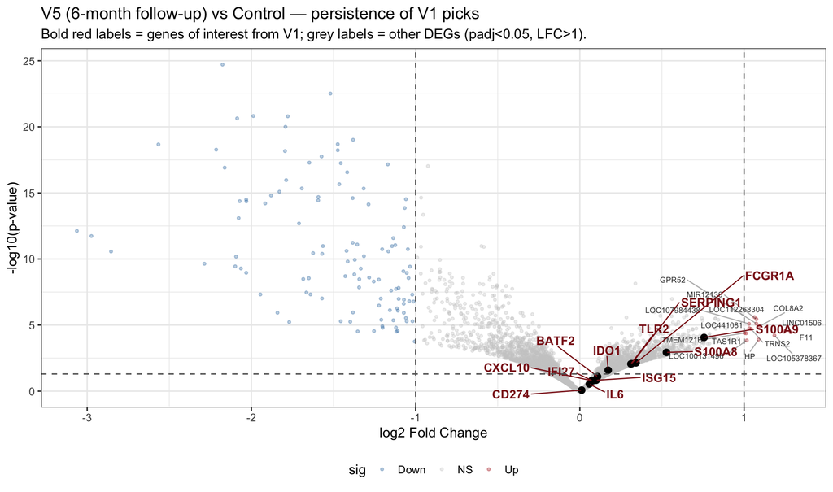

```r
make_volcano_v5_persist <- function(df, title, highlight, max_labels = 25) {
  df <- df %>%
    dplyr::mutate(sig = dplyr::case_when(
      is.na(padj) ~ "NS",
      padj < 0.05 & log2FoldChange > 1  ~ "Up",
      padj < 0.05 & log2FoldChange < -1 ~ "Down",
      TRUE ~ "NS"))

  hl    <- df %>% dplyr::filter(Symbol %in% highlight)
  up_lab <- df %>%
    dplyr::filter(sig == "Up" & !(Symbol %in% highlight)) %>%
    dplyr::arrange(padj) %>%
    head(max_labels)

  ggplot(df, aes(x = log2FoldChange, y = -log10(pvalue))) +
    geom_point(aes(color = sig), alpha = 0.35, size = 1) +
    # other significantly up genes — small grey labels
    geom_text_repel(data = up_lab, aes(label = Symbol),
                    size = 2.6, color = "gray25",
                    max.overlaps = 60, box.padding = 0.3,
                    segment.alpha = 0.4) +
    # genes of interest — bold, dark red, larger
    geom_point(data = hl, color = "black", size = 2.6) +
    geom_text_repel(data = hl, aes(label = Symbol),
                    size = 4, fontface = "bold", color = "firebrick4",
                    box.padding = 0.6, max.overlaps = 60) +
    scale_color_manual(values = c(Up = "firebrick", Down = "steelblue", NS = "gray80")) +
    geom_vline(xintercept = c(-1, 1), linetype = "dashed", color = "gray40") +
    geom_hline(yintercept = -log10(0.05), linetype = "dashed", color = "gray40") +
    labs(title    = title,
         subtitle = "Bold red labels = genes of interest from V1; grey labels = other DEGs (padj<0.05, LFC>1).",
         x = "log2 Fold Change", y = "-log10(p-value)") +
    theme(legend.position = "bottom")
}

make_volcano_v5_persist(res_list$V5,
                        "V5 (6-month follow-up) vs Control — persistence of V1 picks",
                        genes_of_interest)
```

### Cross-time-point summary for the genes of interest

A single table that joins the V1, V2, V5 numbers for every pick, useful for the report and for spotting which genes resolve and which persist.

```r
goi_long <- dplyr::bind_rows(
  res_list$V1 %>% dplyr::filter(Symbol %in% genes_of_interest) %>%
    dplyr::transmute(Symbol, timepoint = "V1",
                     log2FoldChange, padj),
  res_list$V2 %>% dplyr::filter(Symbol %in% genes_of_interest) %>%
    dplyr::transmute(Symbol, timepoint = "V2",
                     log2FoldChange, padj),
  res_list$V5 %>% dplyr::filter(Symbol %in% genes_of_interest) %>%
    dplyr::transmute(Symbol, timepoint = "V5",
                     log2FoldChange, padj)
)

goi_wide <- goi_long %>%
  dplyr::mutate(sig = !is.na(padj) & padj < 0.05 & abs(log2FoldChange) > 1) %>%
  dplyr::select(-padj) %>%
  tidyr::pivot_wider(names_from = timepoint,
                     values_from = c(log2FoldChange, sig),
                     names_glue = "{.value}_{timepoint}") %>%
  dplyr::arrange(dplyr::desc(log2FoldChange_V1))
print(goi_wide)
```

```
## # A tibble: 12 × 7
##    Symbol   log2FoldChange_V1 log2FoldChange_V2 log2FoldChange_V5 sig_V1 sig_V2 sig_V5
##    <chr>                <dbl>             <dbl>             <dbl> <lgl>  <lgl>  <lgl>
##  1 BATF2                 3.78             1.07             0.108  TRUE   TRUE   FALSE
##  2 IDO1                  3.74             2.69             0.173  TRUE   TRUE   FALSE
##  3 SERPING1              3.64             0.708            0.316  TRUE   FALSE  FALSE
##  4 IFI27                 3.58             0.561            0.0730 TRUE   FALSE  FALSE
##  5 FCGR1A                3.46             0.987            0.342  TRUE   FALSE  FALSE
##  6 CXCL10                2.70             3.76             0.0769 TRUE   TRUE   FALSE
##  7 CD274                 2.33             1.08             0.0113 TRUE   TRUE   FALSE
##  8 S100A9                2.16             1.01             0.757  TRUE   TRUE   FALSE
##  9 S100A8                2.15             0.742            0.527  TRUE   FALSE  FALSE
## 10 ISG15                 2.09             2.16             0.0996 TRUE   TRUE   FALSE
## 11 IL6                   1.71             0.851            0.0578 TRUE   FALSE  FALSE
## 12 TLR2                  1.48             0.827            0.311  TRUE   FALSE  FALSE
```

[figure not shown]

```r
ggplot(goi_long,
       aes(x = factor(timepoint, levels = c("V1","V2","V5")),
           y = log2FoldChange, group = Symbol, color = Symbol)) +
  geom_line(linewidth = 0.7, alpha = 0.85) +
  geom_point(aes(shape = !is.na(padj) & padj < 0.05 & abs(log2FoldChange) > 1),
             size = 3) +
  scale_shape_manual(values = c(`TRUE` = 16, `FALSE` = 1),
                     labels = c("padj<0.05 & |LFC|>1", "n.s."),
                     name = NULL) +
  geom_hline(yintercept = c(-1, 1), linetype = "dashed", color = "gray60") +
  geom_hline(yintercept = 0, color = "gray40") +
  labs(title = "Genes of interest — LFC trajectory across V1 → V2 → V5",
       subtitle = "Filled circle = significant at that visit. Lines decay = signature is resolving.",
       x = NULL, y = "log2 Fold Change vs Control") +
  theme(legend.position = "right",
        legend.text = element_text(size = 8))
```

This trajectory plot is the simplest visual answer to “does CXCL10 persist?”. Every pick that stays above LFC = 1 (and stays a filled circle) at V5 is a candidate persistence biomarker, every pick that decays below the dashed line by V5 is a marker of acute infection that resolves.

### genes of interest

**1. CXCL10 (IP-10): the strongest published Lyme biomarker candidate**

CXCL10 is an IFN-γ-induced chemokine that recruits activated T cells (Th1) and NK cells to sites of infection. Soloski *et al.* (2014, *PLoS ONE*) showed CXCL10 is significantly elevated in serum of patients with erythema migrans and **stays elevated in patients who develop post-treatment Lyme disease syndrome (PTLDS)**, making it the leading transcriptional/serum biomarker for the persistent signature. Aucott *et al.* (2016) and Strle *et al.* (2014) reach similar conclusions. Our V1 result (large positive LFC, very small padj) directly recapitulates this finding at the transcriptome level.

**2. S100A8 / S100A9 (calprotectin / MRP8-MRP14): neutrophil alarmins**

S100A8 and S100A9 form the heterodimer **calprotectin**, a damage-associated molecular pattern (DAMP) released by activated neutrophils and monocytes. They directly activate **TLR4** and **RAGE**, amplifying NF-κB-driven inflammation. Calprotectin is established as a serum/synovial biomarker in **Lyme arthritis** (Wang *et al.* 2016, *Clin Vaccine Immunol*) and is elevated in many bacterial infections. Our LFC > 2 with very small padj is consistent with massive neutrophil activation in acute Lyme.

**3. FCGR1A (CD64): classic monocyte activation marker**

CD64 is the high-affinity Fc-γ receptor on monocytes/macrophages. Its surface expression is one of the most validated clinical sepsis/bacterial-infection markers (Cid *et al.* 2010 meta-analysis). Strong upregulation at V1 confirms a bacterial-infection-like activation profile and matches the original paper’s emphasis on macrophage activation.

**4. TLR2: direct sensor of Borrelia burgdorferi**

TLR2 (with TLR1) recognises the **outer surface lipoproteins (OspA, OspC)** of *B. burgdorferi*. Hirschfeld *et al.* (1999, *J Immunol*) and Wooten *et al.* (2002) established this is the principal innate-immunity entry point for Lyme. Its upregulation at V1 is mechanistically central — it is the molecular receptor for the pathogen.

**5. IDO1: immunoregulatory tryptophan metabolism**

IDO1 catalyses tryptophan → kynurenine, depleting tryptophan locally and producing immunosuppressive metabolites. It is induced by IFN-γ and is a candidate driver of T-cell hypofunction in **chronic infections** (Lyme, TB, HCV, HIV). Mellor & Munn (2004, *Nat Rev Immunol*) review this. If your story is “why does the immune signal *persist* after antibiotics?”, IDO1 is a strong candidate mechanism.

**6. CD274 (PD-L1): immune checkpoint / exhaustion**

PD-L1 binds PD-1 on T cells and dampens their response. Persistent PD-L1 expression is a hallmark of **T-cell exhaustion** in chronic viral and bacterial infections (Wherry 2011, *Nat Immunol*). Its elevation at V1 (and persistence at V2 in our results) is consistent with the host beginning to apply a “brake” to the inflammatory response, relevant to the “the signature persists” narrative.

**7. ISG15 / IFI27 / BATF2: Interferon-stimulated genes (ISGs)**

These three are core ISGs and routinely sit at the top of Type-I interferon response scores (Mostafavi *et al.* 2016). Their large LFCs at V1 explain why both `HALLMARK_INTERFERON_GAMMA_RESPONSE` and `HALLMARK_INTERFERON_ALPHA_RESPONSE` light up so strongly in ORA/GSEA. Worth mentioning collectively as “the IFN signature”.

## 10.7 DEG Overlap Across Time Points

```r
sig_genes <- lapply(res_list, function(df)
  df %>% dplyr::filter(!is.na(padj) & padj < 0.05 & abs(log2FoldChange) > 1) %>%
    dplyr::pull(GeneID))

cat("V1:", length(sig_genes$V1), "  V2:", length(sig_genes$V2),
    "  V5:", length(sig_genes$V5), "\n")
```

```
## V1: 1020   V2: 549   V5: 125
```

```r
cat("V1 & V2:", length(intersect(sig_genes$V1, sig_genes$V2)), "\n")
```

```
## V1 & V2: 288
```

```r
cat("V1 & V5:", length(intersect(sig_genes$V1, sig_genes$V5)), "\n")
```

```
## V1 & V5: 70
```

```r
cat("All 3:  ", length(Reduce(intersect, sig_genes)), "\n")
```

```
## All 3:   62
```

The overlap between V1 and V2 tells us how many genes remain differentially expressed even after antibiotic treatment.

## 10.8 Save DEG Tables

```r
for (nm in names(res_list))
  write.csv(res_list[[nm]],
            file.path(results_dir, paste0("DEG_", nm, "_vs_Control.csv")),
            row.names = FALSE)
```

# 11. 1st Generation: ORA (Over-Representation Analysis)

*Ref: Thomas’s book Ch. 8.1.1, 8.4.1; Khatri et al. 2012*

ORA asks: “Are my DEGs enriched in known pathways more than expected by chance?” It compares the fraction of DEGs in a pathway to the background fraction (all tested genes).

## 11.1 Load MSigDB Gene Sets (targeted)

MSigDB is the companion database for GSEA (second gen. of pathway analysis). but it can also be used for ORA

I loaded only the collections we need to avoid memory issues. Otherwise I couldn’t knit. The full MSigDB is ~738 MB and crashes knitr’s cache.

```r
msigdb_hallmark <- msigdbr(species = "Homo sapiens", collection = "H")
msigdb_gobp     <- msigdbr(species = "Homo sapiens", collection = "C5",
                            subcollection = "GO:BP")

cat("Hallmark:", nrow(msigdb_hallmark), "entries (",
    length(unique(msigdb_hallmark$gs_name)), "sets)\n")
```

```
## Hallmark: 7331 entries ( 50 sets)
```

```r
cat("GO:BP:  ", nrow(msigdb_gobp), "entries (",
    length(unique(msigdb_gobp$gs_name)), "sets)\n")
```

```
## GO:BP:   622397 entries ( 7538 sets)
```

```r
# Hallmark
t2g_hallmark <- msigdb_hallmark %>%
  dplyr::select(gs_name, gene_symbol)

# GO Biological Process
t2g_gobp <- msigdb_gobp %>%
  dplyr::select(gs_name, gene_symbol)
t2n_gobp <- msigdb_gobp %>%
  dplyr::select(gs_name, gs_description) %>%
  dplyr::distinct()
```

## 11.2 ORA: Hallmark across all time points (V1, V2, V5)

We run the same Hallmark ORA at each visit so the persistence/resolution pattern is visible at the pathway level, not just for V1. This block also computes the per-timepoint significant-gene and universe vectors used by other sections (11.3 GO:BP, 15.4 SPIA cross-DB).

```r
sig_sym_per_tp <- lapply(res_list, function(df) {
  df %>%
    dplyr::filter(!is.na(padj) & padj < 0.05 & abs(log2FoldChange) > 1 &
                  !is.na(Symbol) & Symbol != "") %>%
    dplyr::pull(Symbol) %>% unique()
})
univ_sym_per_tp <- lapply(res_list, function(df) {
  df %>%
    dplyr::filter(!is.na(Symbol) & Symbol != "") %>%
    dplyr::pull(Symbol) %>% unique()
})

ora_hallmark_all <- list()
for (tp in names(res_list)) {
  ora_hallmark_all[[tp]] <- enricher(
    gene         = sig_sym_per_tp[[tp]],
    universe     = univ_sym_per_tp[[tp]],
    TERM2GENE    = t2g_hallmark,
    pvalueCutoff = 0.05,
    pAdjustMethod = "BH",
    qvalueCutoff = 1
  )
}

# Backward-compatible aliases for sections that consume the V1-only objects
sig_sym_v1      <- sig_sym_per_tp$V1
univ_sym        <- univ_sym_per_tp$V1
ora_hallmark_v1 <- ora_hallmark_all$V1

cat("Enriched Hallmark pathways (padj<0.05, BH):",
    "  V1 =", nrow(as.data.frame(ora_hallmark_all$V1)),
    "| V2 =", nrow(as.data.frame(ora_hallmark_all$V2)),
    "| V5 =", nrow(as.data.frame(ora_hallmark_all$V5)), "\n")
```

```
## Enriched Hallmark pathways (padj<0.05, BH):   V1 = 9 | V2 = 6 | V5 = 0
```

`pAdjustMethod = "BH"` is Benjamini-Hochberg multiple-testing correction. `qvalueCutoff = 1` disables an additional q-value filter so we only rely on the BH-adjusted p-values; we can revisit this if Thomas wants stricter control.

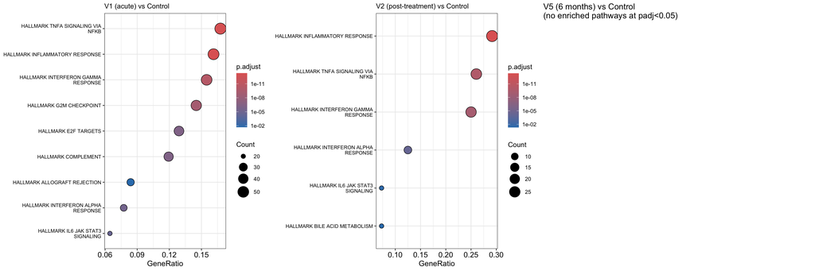

```r
plot_ora_dotplot <- function(ora_obj, title) {
  if (is.null(ora_obj) || nrow(as.data.frame(ora_obj)) == 0)
    return(ggplot() + theme_void() +
           ggtitle(paste(title, "\n(no enriched pathways at padj<0.05)")))
  dotplot(ora_obj, showCategory = 15) +
    ggtitle(title) +
    theme(axis.text.y = element_text(size = 8),
          plot.title  = element_text(size = 11))
}

grid.arrange(
  plot_ora_dotplot(ora_hallmark_all$V1, "V1 (acute) vs Control"),
  plot_ora_dotplot(ora_hallmark_all$V2, "V2 (post-treatment) vs Control"),
  plot_ora_dotplot(ora_hallmark_all$V5, "V5 (6 months) vs Control"),
  ncol = 3
)
```

A cross-time-point heatmap of `-log10(padj)` for every Hallmark significant in at least one timepoint is built below to make the V1 → V2 → V5 dynamics quantitative.

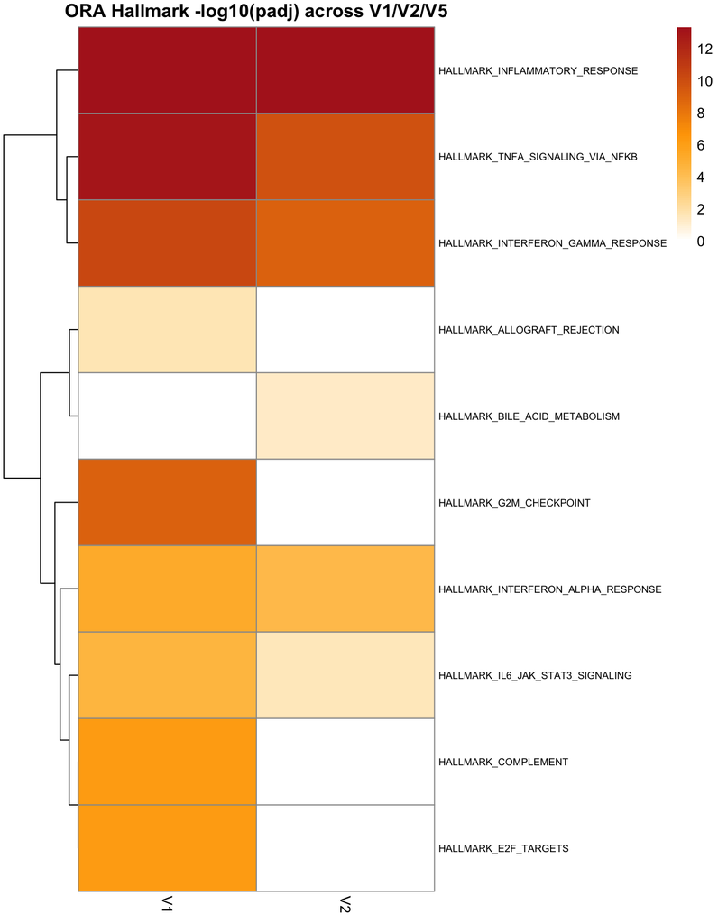

```r
ora_long <- dplyr::bind_rows(lapply(names(ora_hallmark_all), function(tp) {
  df <- as.data.frame(ora_hallmark_all[[tp]])
  if (nrow(df) == 0) return(NULL)
  df %>% dplyr::transmute(ID, p.adjust, timepoint = tp)
}))

if (nrow(ora_long) > 0) {
  ora_mat <- ora_long %>%
    dplyr::mutate(score = -log10(p.adjust)) %>%
    dplyr::select(ID, timepoint, score) %>%
    tidyr::pivot_wider(names_from = timepoint, values_from = score) %>%
    tibble::column_to_rownames("ID") %>% as.matrix()
  ora_mat[is.na(ora_mat)] <- 0
  ora_mat <- ora_mat[, intersect(c("V1","V2","V5"), colnames(ora_mat)), drop = FALSE]

  pheatmap(ora_mat,
           color = colorRampPalette(c("white","orange","firebrick"))(100),
           cluster_cols = FALSE,
           main = "ORA Hallmark -log10(padj) across V1/V2/V5",
           fontsize_row = 7)
} else {
  cat("No enriched Hallmarks across any time point.\n")
}
```

### 11.2.1 Top hit explained: `HALLMARK_TNFA_SIGNALING_VIA_NFKB`

This is the #1 enriched pathway in our V1 ORA (and also in GSEA, Section 12). Both Bouquet *et al.* (2016) and our re-analysis identify it as central to the acute Lyme response. Here is what it means biologically.

#### What is TNF-α?

**Tumour Necrosis Factor alpha (TNF-α)** is a master pro-inflammatory cytokine. It is secreted mainly by activated macrophages, monocytes, and T cells in response to a pathogen. Once released, it binds two receptors on neighbouring cells:

- **TNFR1** (ubiquitously expressed) → triggers the NF-κB signalling cascade (and, in some contexts, apoptosis).
- **TNFR2** (mainly on immune cells) → activates NF-κB and survival/proliferation programmes.

#### What is NF-κB?

**Nuclear Factor kappa-light-chain-enhancer of activated B cells (NF-κB)** is a transcription-factor family (RELA/p65, RELB, c-REL, NFKB1, NFKB2). In a resting cell it sits in the cytoplasm bound to its inhibitor **IκBα**. When TNF-α (or LPS, IL-1, TLR ligands) signals into the cell, **IκBα is phosphorylated and degraded**, freeing NF-κB to translocate into the nucleus. There it binds κB sites in promoters and rapidly switches on **hundreds of inflammatory, anti-apoptotic, and remodelling genes** — within minutes, without needing new protein synthesis.

#### Why this pathway dominates V1

Acute *B. burgdorferi* infection activates innate sensors (TLR2, TLR1/6, NOD2). These converge on the canonical IKK → NF-κB axis, and the cell amplifies the signal through an **autocrine loop**: NF-κB transcribes *TNF*, *IL6*, *IL1B*, and the chemokines *CXCL8/CXCL10/CXCL11*, which themselves re-engage their receptors and feed NF-κB again. That is why a single innate trigger looks like a coordinated “storm” in our transcriptome.

#### Key genes in our leading edge (from V1 GSEA)

These are the genes that drove the high enrichment score for this pathway in our data, most are upregulated and are textbook NF-κB targets:

| Gene | Class | What it does |
| --- | --- | --- |
| **TNF / TNFAIP3 / TNFAIP6** | Cytokine + feedback | TNFAIP3 (A20) is a deubiquitinase that brakes NF-κB — its induction is a self-limiting feedback loop. |
| **NFKB1 / NFKB2 / REL / RELB / NFKBIA / NFKBIE / BCL3** | The pathway itself | Subunits and inhibitors of NF-κB; their own transcription is induced by NF-κB (positive autoregulation). |
| **IL6 / IL1A / IL1B** | Pro-inflammatory cytokines | Drive fever, acute-phase response, and sustain the storm. |
| **CXCL1 / CXCL2 / CXCL3 / CXCL10 / CXCL11 / CCL2 / CCL4 / CCL20** | Chemokines | Recruit neutrophils (CXCL1-3), monocytes (CCL2), Th1 cells (CXCL10/11). |
| **ICAM1 / VCAM1** | Adhesion | Allow leukocytes to stick to endothelium and exit blood vessels. |
| **PTGS2 (COX-2)** | Enzyme | Produces prostaglandins (the molecules NSAIDs/aspirin block). |
| **SOD2 / NOS2 / NQO1** | Oxidative defence | Manage the ROS released by activated macrophages. |
| **BCL2A1 / BIRC2 / BIRC3** | Anti-apoptotic | Keep activated immune cells alive long enough to fight. |
| **MYC / EGR1 / FOS / JUN** | Immediate-early TFs | Boost proliferation of activated cells. |

Many of these (CXCL10, IL6, ICAM1) overlap with the **Inflammatory Response** and **IFN-γ Response** Hallmarks below, that overlap is real biology, not redundancy.

#### What are pro-inflammatory cytokines?

**Cytokines** are small (~5–20 kDa) signalling proteins released by immune (and other) cells. **Pro-inflammatory** cytokines amplify the response — they recruit cells, raise body temperature, increase vascular permeability, and induce acute-phase liver proteins. The canonical set is:

| Cytokine | Main source | Main effect |
| --- | --- | --- |
| **TNF-α** | Macrophages, T cells | NF-κB activation, fever, vascular leak; the “master” pro-inflammatory cytokine |
| **IL-1α / IL-1β** | Macrophages, monocytes | Fever, NF-κB; IL-1β is processed by the inflammasome |
| **IL-6** | Macrophages, T cells, fibroblasts | Acute-phase proteins (CRP), fever, B-cell help; biomarker of severity |
| **IL-8 (CXCL8)** | Macrophages, epithelial | Neutrophil recruitment |
| **IL-12 / IL-23** | Dendritic cells, macrophages | Drive Th1 / Th17 differentiation |
| **IL-17 / IL-22** | Th17 cells | Recruit neutrophils, antimicrobial peptides |
| **IL-18** | Macrophages | Synergises with IL-12 for IFN-γ production |
| **IFN-γ** | T cells (Th1), NK cells | Macrophage activation, antiviral state, MHC-II upregulation |
| **GM-CSF (CSF2)** | T cells, macrophages | Granulocyte / macrophage proliferation |

#### Sources:

- Liu *et al.*, **NF-κB signaling in inflammation**, *Signal Transduction and Targeted Therapy* (2017).
- Pasparakis, **Regulation of tissue homeostasis by NF-κB**, *Nat Rev Immunol* (2009).
- Hayden & Ghosh, **Shared principles in NF-κB signaling**, *Cell* (2008).
- Bouquet *et al.* 2016, *mBio* — original Lyme RNA-seq study.
- Soloski *et al.* 2014 *PLoS ONE* (CXCL10 in Lyme).

## 11.3 ORA: GO Biological Process across all time points

1. **Save the full result** to `results/ORA_GOBP_<tp>.csv` for reproducibility / reviewability.
2. **Plot only the top 15** by adjusted p-value so the figure stays readable.

```r
ora_gobp_all <- list()
for (tp in names(res_list)) {
  ora_gobp_all[[tp]] <- enricher(
    gene         = sig_sym_per_tp[[tp]],
    universe     = univ_sym_per_tp[[tp]],
    TERM2GENE    = t2g_gobp,
    TERM2NAME    = t2n_gobp,
    pvalueCutoff = 0.05,
    pAdjustMethod = "BH",
    qvalueCutoff = 1
  )
}

# Backward-compat alias (older sections / SPIA cross-DB still expect ora_gobp_v1)
ora_gobp_v1    <- ora_gobp_all$V1
ora_gobp_v1_df <- as.data.frame(ora_gobp_v1) %>% dplyr::arrange(p.adjust)

for (tp in names(ora_gobp_all)) {
  df <- as.data.frame(ora_gobp_all[[tp]]) %>% dplyr::arrange(p.adjust)
  cat("GO:BP terms enriched at", tp, ":", nrow(df), "\n")
  write.csv(df,
            file.path(results_dir, paste0("ORA_GOBP_", tp, ".csv")),
            row.names = FALSE)
}
```

```
## GO:BP terms enriched at V1 : 423
## GO:BP terms enriched at V2 : 61
## GO:BP terms enriched at V5 : 0
```

```r
cat("Full GO:BP tables saved to results/ORA_GOBP_{V1,V2,V5}.csv\n")
```

```
## Full GO:BP tables saved to results/ORA_GOBP_{V1,V2,V5}.csv
```

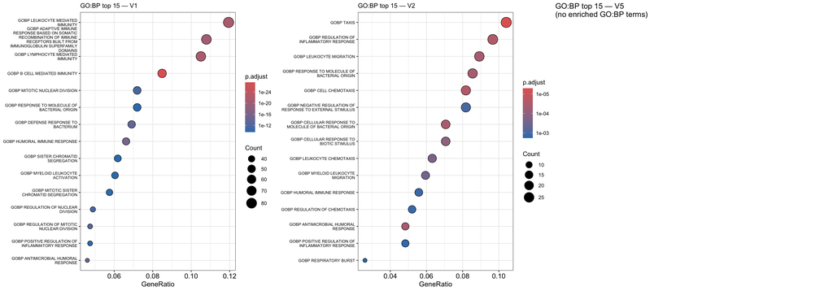

```r
plot_gobp_dotplot <- function(ora_obj, title, n = 15) {
  if (is.null(ora_obj) || nrow(as.data.frame(ora_obj)) == 0)
    return(ggplot() + theme_void() +
           ggtitle(paste(title, "\n(no enriched GO:BP terms)")))
  top <- ora_obj
  top@result <- top@result %>%
    dplyr::arrange(p.adjust) %>%
    head(n) %>%
    dplyr::mutate(
      # Overwrite Description with ID so dotplot uses the unique name instead of description
      Description = ID
    )
  dotplot(top, showCategory = n) +
    ggtitle(title) +
    theme(axis.text.y = element_text(size = 7),
          plot.title  = element_text(size = 11))
}

grid.arrange(
  plot_gobp_dotplot(ora_gobp_all$V1, "GO:BP top 15 — V1"),
  plot_gobp_dotplot(ora_gobp_all$V2, "GO:BP top 15 — V2"),
  plot_gobp_dotplot(ora_gobp_all$V5, "GO:BP top 15 — V5"),
  ncol = 3
)
```

## 11.4 ORA narrative summary across time points

# 12. 2nd Generation: GSEA (Gene Set Enrichment Analysis)

*Ref: Thomas’s book Ch. 8.1.2.1, 8.4.3; Subramanian et al. 2005*

GSEA is a major improvement over ORA because it uses **all genes ranked by fold change**, not just those passing an arbitrary significance cutoff. It detects subtle, coordinated changes in pathways that ORA misses. The original study did NOT perform GSEA. This is a novel contribution of our re-analysis.

## 12.1 Build Ranked Gene Lists

GSEA needs every gene ranked by some continuous score. There is no single “right” choice, and the literature uses several:

- **By log2 fold change (LFC).** Simple and intuitive. **Drawback:** low-expression genes with very large but unreliable LFCs can dominate the top of the list. This is the default in many tutorials.
- **By signed −log10(p).** `sign(LFC) × −log10(pvalue)`. Combines effect size (sign) with statistical confidence (magnitude). **Drawback:** purely tiny p-values can be inflated by very high counts; conversely, a gene with massive biological LFC but a borderline p-value is pushed down.

We compute **both** rankings so we can run GSEA with each and cross-check that the conclusions are robust to the ranking choice.

```r
# Ranker A: sort by raw log2 fold change (default in many tutorials)
make_ranked_list_lfc <- function(res_df) {
  res_df %>%
    dplyr::filter(!is.na(Symbol) & Symbol != "" & !is.na(log2FoldChange)) %>%
    dplyr::arrange(dplyr::desc(log2FoldChange)) %>%
    dplyr::distinct(Symbol, .keep_all = TRUE) %>%
    dplyr::select(Symbol, log2FoldChange) %>%
    tibble::deframe()
}

# Ranker B: signed -log10(p-value) -- combines direction with statistical confidence
make_ranked_list_signedp <- function(res_df) {
  res_df %>%
    dplyr::filter(!is.na(Symbol) & Symbol != "" &
                  !is.na(log2FoldChange) & !is.na(pvalue)) %>%
    dplyr::mutate(stat = sign(log2FoldChange) *
                         -log10(pmax(pvalue, 1e-300))) %>%
    dplyr::arrange(dplyr::desc(stat)) %>%
    dplyr::distinct(Symbol, .keep_all = TRUE) %>%
    dplyr::select(Symbol, stat) %>%
    tibble::deframe()
}

# Default for the rest of the document: LFC ranker (kept for backward compatibility)
make_ranked_list <- make_ranked_list_lfc
ranked_lists       <- lapply(res_list, make_ranked_list_lfc)
ranked_lists_sigp  <- lapply(res_list, make_ranked_list_signedp)

cat("V1 ranking sanity check\n")
```

```
## V1 ranking sanity check
```

```r
cat("  LFC-ranked top 5:    ", paste(head(names(ranked_lists$V1), 5),     collapse = ", "), "\n")
```

```
##   LFC-ranked top 5:     IGLV9-49, ANKRD22, LIPM, IGLV3-10, ACOD1
```

```r
cat("  signed-p top 5:      ", paste(head(names(ranked_lists_sigp$V1), 5), collapse = ", "), "\n")
```

```
##   signed-p top 5:       RRM2, S100A9, MKI67, ASPM, FCGR1CP
```

```r
cat("  LFC-ranked bottom 5: ", paste(tail(names(ranked_lists$V1), 5),     collapse = ", "), "\n")
```

```
##   LFC-ranked bottom 5:  LINC01013, LOC112268106, MYOZ2, WNT3, CFAP20DC
```

```r
cat("  signed-p bottom 5:   ", paste(tail(names(ranked_lists_sigp$V1), 5), collapse = ", "), "\n")
```

```
##   signed-p bottom 5:    LINC01278, RUSF1, ALKBH2, TP53I13, SYTL1
```

## 12.2 GSEA: Hallmark across all time points (V1, V2, V5)

We run the same Hallmark GSEA at every visit and reuse the resulting `gsea_results` for every per-timepoint figure that follows (dotplots, GSEA volcanoes, ORA↔︎GSEA validation, ranker robustness, NES heatmap). This gives a single source of truth for all GSEA-based outputs.

```r
gsea_results <- list()
for (tp in names(ranked_lists))
  gsea_results[[tp]] <- GSEA(geneList     = ranked_lists[[tp]],
                              TERM2GENE    = t2g_hallmark,
                              pvalueCutoff = 1, eps = 0)

# Backward-compatible aliases used by SPIA cross-DB and elsewhere
gsea_hallmark_v1 <- gsea_results$V1

gsea_h_df <- as.data.frame(gsea_hallmark_v1)
cat("V! Significant (padj<0.05):", sum(gsea_h_df$p.adjust < 0.05),
    "of", nrow(gsea_h_df), "pathways\n")
```

```
## V! Significant (padj<0.05): 36 of 50 pathways
```

```r
gsea_hallmark_v2 <- gsea_results$V2
gsea_h_df <- as.data.frame(gsea_hallmark_v2)
cat("V2 Significant (padj<0.05):", sum(gsea_h_df$p.adjust < 0.05),
    "of", nrow(gsea_h_df), "pathways\n")
```

```
## V2 Significant (padj<0.05): 17 of 50 pathways
```

```r
gsea_hallmark_v5 <- gsea_results$V5
gsea_h_df <- as.data.frame(gsea_hallmark_v5)
cat("V5 Significant (padj<0.05):", sum(gsea_h_df$p.adjust < 0.05),
    "of", nrow(gsea_h_df), "pathways\n")
```

```
## V5 Significant (padj<0.05): 6 of 50 pathways
```

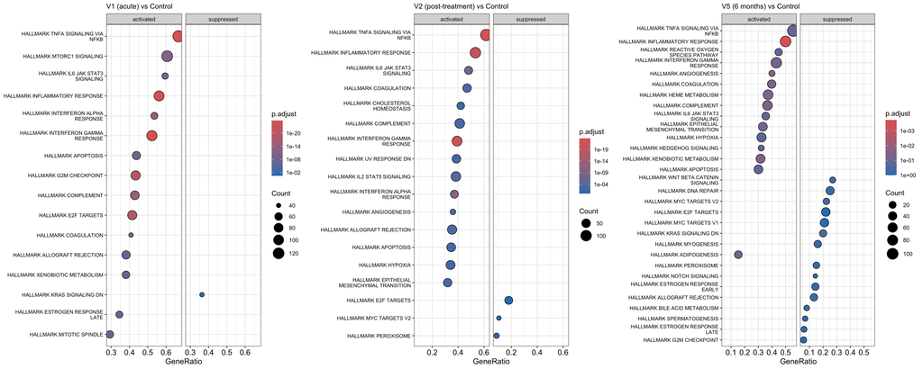

```r
plot_gsea_dotplot <- function(g, title) {
  df <- as.data.frame(g)
  if (nrow(df) == 0 || sum(df$p.adjust < 0.05, na.rm = TRUE) == 0)
    return(ggplot() + theme_void() +
           ggtitle(paste(title, "\n(no Hallmark pathways at padj<0.05)")))
  dotplot(g, showCategory = 15, split = ".sign") +
    facet_grid(~ .sign) +
    ggtitle(title) +
    theme(axis.text.y = element_text(size = 8),
          plot.title  = element_text(size = 11))
}

grid.arrange(
  plot_gsea_dotplot(gsea_results$V1, "V1 (acute) vs Control"),
  plot_gsea_dotplot(gsea_results$V2, "V2 (post-treatment) vs Control"),
  plot_gsea_dotplot(gsea_results$V5, "V5 (6 months) vs Control"),
  ncol = 3
)
```

Each panel splits Hallmark pathways into **activated** (enriched in upregulated genes) and **suppressed** (enriched in downregulated genes). The **Normalised Enrichment Score (NES)** measures how strongly the pathway’s genes cluster at the top (activated) or bottom (suppressed) of the ranked list.

## 12.2b GSEA “volcano” — NES vs significance, all Hallmarks at every visit

The pathway-level analogue of the gene-level volcano in Section 10.5: x-axis is NES (sign = direction), y-axis is `-log10(p.adjust)`. Three panels, one per visit, make the V1 → V2 → V5 *amplitude decay* visually unmistakable.

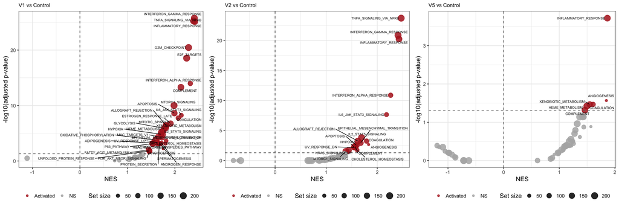

```r
plot_gsea_volcano <- function(g, title) {
  df <- as.data.frame(g) %>%
    dplyr::mutate(
      direction = ifelse(NES > 0, "Activated", "Suppressed"),
      sig       = ifelse(p.adjust < 0.05, direction, "NS"),
      label     = ifelse(p.adjust < 0.05, gsub("HALLMARK_", "", ID), NA)
    )
  ggplot(df, aes(x = NES, y = -log10(p.adjust))) +
    geom_point(aes(color = sig, size = setSize), alpha = 0.85) +
    scale_color_manual(values = c(Activated = "firebrick",
                                  Suppressed = "steelblue",
                                  NS = "gray70")) +
    geom_text_repel(aes(label = label), size = 2.5,
                    max.overlaps = 25, na.rm = TRUE) +
    geom_hline(yintercept = -log10(0.05), linetype = "dashed", color = "gray40") +
    geom_vline(xintercept = 0, linetype = "dashed", color = "gray40") +
    labs(title = title, x = "NES",
         y = "-log10(adjusted p-value)",
         color = NULL, size = "Set size") +
    theme(legend.position = "bottom",
          plot.title = element_text(size = 11))
}

grid.arrange(
  plot_gsea_volcano(gsea_results$V1, "V1 vs Control"),
  plot_gsea_volcano(gsea_results$V2, "V2 vs Control"),
  plot_gsea_volcano(gsea_results$V5, "V5 vs Control"),
  ncol = 3
)
```

The y-axis shrinks from V1 → V2 → V5: fewer pathways pass `padj < 0.05`, and those that do sit closer to the dashed line. The x-axis usually keeps its sign: pathways that are red (activated) at V1 stay red at V5 if they survive, never flipping to blue. This is the GSEA-level confirmation that the residual V5 signature is a *low-amplitude V1* rather than a different biology.

## 12.2c Validation: ORA ↔︎ GSEA agreement at every visit

For each visit we plot ORA `-log10(padj)` against GSEA `-log10(padj)` for shared Hallmark IDs. Top-right (red) points are **significant in both methods** the most robust hits. Pathways significant only in GSEA (left-of-vertical, above-of-horizontal) are GSEA’s “subtle coordinated changes” advantage.

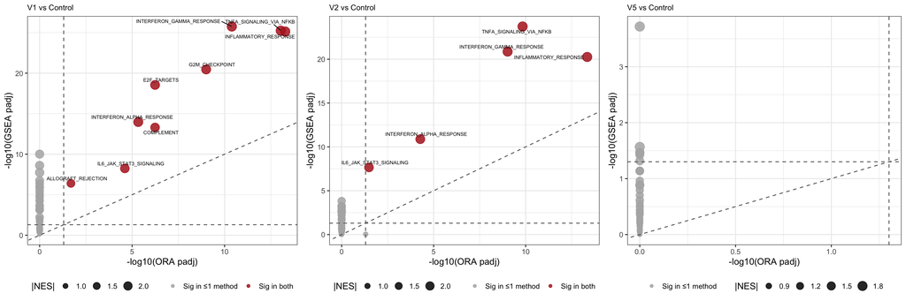

```r
make_concord <- function(ora_obj, gsea_obj, title) {
  ora_df  <- as.data.frame(ora_obj) %>%
    dplyr::transmute(ID, ora_padj = p.adjust)
  gsea_df <- as.data.frame(gsea_obj) %>%
    dplyr::transmute(ID, gsea_padj = p.adjust, NES)
  if (nrow(ora_df) == 0 && nrow(gsea_df) == 0)
    return(ggplot() + theme_void() +
           ggtitle(paste(title, "\n(no enrichment in either method)")))
  d <- dplyr::full_join(ora_df, gsea_df, by = "ID") %>%
    dplyr::mutate(
      ora_padj  = ifelse(is.na(ora_padj),  1, ora_padj),
      gsea_padj = ifelse(is.na(gsea_padj), 1, gsea_padj),
      label     = gsub("HALLMARK_", "", ID),
      both_sig  = (ora_padj < 0.05) & (gsea_padj < 0.05)
    )
  ggplot(d, aes(x = -log10(ora_padj), y = -log10(gsea_padj))) +
    geom_point(aes(color = both_sig, size = abs(NES)), alpha = 0.85) +
    scale_color_manual(values = c(`TRUE` = "firebrick", `FALSE` = "gray70"),
                       labels = c("Sig in ≤1 method", "Sig in both"),
                       name = NULL) +
    geom_abline(slope = 1, intercept = 0, linetype = "dashed", color = "gray40") +
    geom_hline(yintercept = -log10(0.05), linetype = "dashed", color = "gray40") +
    geom_vline(xintercept = -log10(0.05), linetype = "dashed", color = "gray40") +
    geom_text_repel(data = d %>% dplyr::filter(both_sig),
                    aes(label = label), size = 2.5, max.overlaps = 25) +
    labs(title = title, x = "-log10(ORA padj)", y = "-log10(GSEA padj)",
         size = "|NES|") +
    theme(legend.position = "bottom",
          plot.title = element_text(size = 11))
}

grid.arrange(
  make_concord(ora_hallmark_all$V1, gsea_results$V1, "V1 vs Control"),
  make_concord(ora_hallmark_all$V2, gsea_results$V2, "V2 vs Control"),
  make_concord(ora_hallmark_all$V5, gsea_results$V5, "V5 vs Control"),
  ncol = 3
)
```

```r
# Print the both-sig counts in a single line per visit
for (tp in names(gsea_results)) {
  ora_df  <- as.data.frame(ora_hallmark_all[[tp]]) %>% dplyr::transmute(ID, ora_padj = p.adjust)
  gsea_df <- as.data.frame(gsea_results[[tp]])     %>% dplyr::transmute(ID, gsea_padj = p.adjust)
  d <- dplyr::full_join(ora_df, gsea_df, by = "ID") %>%
    dplyr::mutate(ora_padj = ifelse(is.na(ora_padj), 1, ora_padj),
                  gsea_padj = ifelse(is.na(gsea_padj), 1, gsea_padj))
  cat("Hallmarks significant in BOTH ORA & GSEA at", tp, ":",
      sum((d$ora_padj < 0.05) & (d$gsea_padj < 0.05)), "\n")
}
```

```
## Hallmarks significant in BOTH ORA & GSEA at V1 : 9
## Hallmarks significant in BOTH ORA & GSEA at V2 : 5
## Hallmarks significant in BOTH ORA & GSEA at V5 : 0
```

At V1 you should see a populous top-right cluster — the V1 acute signal is robust to method. At V2 the cluster shrinks but the same canonical pathways survive (TNFA, Inflammatory, IFN-γ). At V5 the cluster is smallest and may even be empty for ORA (because few V5 genes pass `|LFC|>1, padj<0.05`); GSEA-only points above the horizontal but left-of-vertical are then the *subtle persistent* pathways, exactly the case GSEA was designed for.

## 12.2d Robustness check: GSEA with LFC ranker vs signed −log10(p) ranker, at every visit

Same robustness test as before, run for each visit. Each panel shows NES from the LFC ranker vs NES from the signed-p ranker; tight diagonal clustering of the “Sig in both” points means the result is not an artefact of how we rank the genes.

```r
gsea_results_signedp <- list()
for (tp in names(ranked_lists_sigp))
  gsea_results_signedp[[tp]] <- GSEA(geneList     = ranked_lists_sigp[[tp]],
                                      TERM2GENE    = t2g_hallmark,
                                      pvalueCutoff = 1, eps = 0)
```

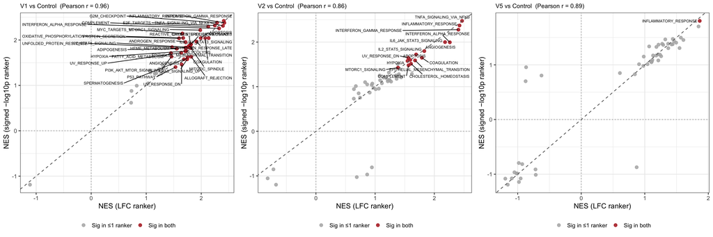

```r
plot_ranker_compare <- function(g_lfc, g_sgp, title) {
  df_lfc <- as.data.frame(g_lfc) %>%
    dplyr::transmute(ID, NES_lfc = NES, padj_lfc = p.adjust)
  df_sgp <- as.data.frame(g_sgp) %>%
    dplyr::transmute(ID, NES_sgp = NES, padj_sgp = p.adjust)
  d <- dplyr::full_join(df_lfc, df_sgp, by = "ID") %>%
    dplyr::mutate(
      padj_lfc = ifelse(is.na(padj_lfc), 1, padj_lfc),
      padj_sgp = ifelse(is.na(padj_sgp), 1, padj_sgp),
      label    = gsub("HALLMARK_", "", ID),
      both_sig = padj_lfc < 0.05 & padj_sgp < 0.05
    )
  rho <- suppressWarnings(cor(d$NES_lfc, d$NES_sgp, use = "complete.obs"))
  ggplot(d, aes(x = NES_lfc, y = NES_sgp)) +
    geom_point(aes(color = both_sig), alpha = 0.85, size = 2.4) +
    scale_color_manual(values = c(`TRUE` = "firebrick", `FALSE` = "gray70"),
                       labels = c("Sig in ≤1 ranker", "Sig in both"),
                       name = NULL) +
    geom_abline(slope = 1, intercept = 0, linetype = "dashed", color = "gray40") +
    geom_hline(yintercept = 0, linetype = "dotted", color = "gray60") +
    geom_vline(xintercept = 0, linetype = "dotted", color = "gray60") +
    geom_text_repel(data = d %>% dplyr::filter(both_sig),
                    aes(label = label), size = 2.5, max.overlaps = 25) +
    labs(title = paste0(title, "  (Pearson r = ", round(rho, 2), ")"),
         x = "NES (LFC ranker)", y = "NES (signed −log10p ranker)") +
    theme(legend.position = "bottom",
          plot.title = element_text(size = 11))
}

grid.arrange(
  plot_ranker_compare(gsea_results$V1, gsea_results_signedp$V1, "V1 vs Control"),
  plot_ranker_compare(gsea_results$V2, gsea_results_signedp$V2, "V2 vs Control"),
  plot_ranker_compare(gsea_results$V5, gsea_results_signedp$V5, "V5 vs Control"),
  ncol = 3
)
```

Pearson correlations near 1 across all three visits mean the GSEA result is genuinely robust to ranker choice at every disease stage, *not* just at V1. If V5 has a noticeably lower correlation it is usually because the V5 signal is small enough that ranker noise matters more (small denominators).

## 12.3 GSEA Enrichment (“mountain”) Plots for Key Pathways — across all visits

For each of the four signature pathways we draw the mountain plot at every visit. The peak height (enrichment score, ES) tracks how strongly the pathway’s genes cluster at the top of the ranked list, visually showing the V1 → V2 → V5 *decay* of each pathway in one figure.